# Cryptocurrency Price Prediction — Combined Analysis

Combines EDA, feature engineering, regression price-prediction, and classification direction-prediction for BTC, ETH, SOL, and ADA.

**Sections**

1. Imports
2. Data Loading & Cleaning
3. Feature Engineering
4. Exploratory Data Analysis
5. Regression Model Comparison (price prediction)
   - 5.1 Regression Ensemble Methods (Weighted Average · Inverse Error Weight · Blending · Stacking)
6. Classification Model Analysis (direction prediction)
7. Hyperparameter Tuning
8. Imbalance Strategy Comparison
9. Final Model Evaluation
   - 9.1 Classification Ensemble Methods (Weighted Average · Inverse Error Weight · Blending · Stacking)
10. Results Summary & Key Insights

## 1. Imports

```python
import os
import warnings
import numpy as np
import pandas as pd
import matplotlib.pyplot as plt
import matplotlib.patches as mpatches
import seaborn as sns
import joblib

import plotly.express as px
import plotly.graph_objects as go
import plotly.io as pio

from sklearn.base import clone
from sklearn.linear_model import LinearRegression, LogisticRegression
from sklearn.ensemble import (
    RandomForestRegressor, RandomForestClassifier, GradientBoostingClassifier,
    StackingRegressor, StackingClassifier
)
from sklearn.svm import SVR
from sklearn.neural_network import MLPClassifier
from sklearn.neighbors import KNeighborsClassifier
from sklearn.tree import DecisionTreeClassifier
from sklearn.preprocessing import StandardScaler
from sklearn.pipeline import Pipeline
from sklearn.impute import SimpleImputer
from sklearn.compose import ColumnTransformer
from sklearn.feature_selection import SelectKBest, f_classif
from sklearn.model_selection import (
    train_test_split, StratifiedKFold, cross_validate, GridSearchCV
)
from sklearn.metrics import (
    mean_absolute_error, mean_squared_error, r2_score,
    accuracy_score, precision_score, recall_score, f1_score,
    roc_auc_score, classification_report, confusion_matrix,
    RocCurveDisplay, PrecisionRecallDisplay
)

from imblearn.pipeline import Pipeline as ImbPipeline
from imblearn.over_sampling import SMOTE
from imblearn.combine import SMOTEENN
from imblearn.under_sampling import RandomUnderSampler

try:
    from xgboost import XGBClassifier, XGBRegressor
    HAS_XGBOOST = True
except ImportError:
    HAS_XGBOOST = False
    print("XGBoost not installed — XGB models will be skipped.")

warnings.filterwarnings("ignore")
pio.renderers.default = "notebook"
plt.rcParams["figure.dpi"] = 100
sns.set_theme(style="whitegrid")
print("All imports OK")
```

```
All imports OK
```

## 2. Data Loading & Cleaning

```python
import yfinance as yf

SYMBOLS = ["BTC-USD", "ETH-USD", "ADA-USD", "SOL-USD"]
PERIOD  = "5y"   # 5 years of daily data


def download_and_clean(symbol):
    raw = yf.download(symbol, period=PERIOD, interval="1d", progress=False, auto_adjust=False)
    if raw is None or raw.empty:
        print(f"WARNING: no data returned for {symbol}")
        return None
    # Flatten MultiIndex columns produced by yfinance >= 0.2
    if isinstance(raw.columns, pd.MultiIndex):
        raw.columns = [col[0] for col in raw.columns]
    df = raw.copy()
    df.index.name = "Date"
    df.reset_index(inplace=True)
    df["Date"] = pd.to_datetime(df["Date"])
    df.rename(columns={"Adj Close": "Adj_Close"}, inplace=True)
    for col in ["Open", "High", "Low", "Close", "Volume"]:
        if col in df.columns:
            df[col] = pd.to_numeric(df[col], errors="coerce")
    df.dropna(subset=["Close"], inplace=True)
    df.sort_values("Date", inplace=True)
    df.reset_index(drop=True, inplace=True)
    df["Symbol"] = symbol
    return df


frames = []
for sym in SYMBOLS:
    result = download_and_clean(sym)
    if result is not None:
        frames.append(result)
        print(f"  {sym}: {len(result):,} rows")

df = pd.concat(frames, ignore_index=True)
print(f"\nTotal: {len(df):,} rows, {df['Symbol'].nunique()} coins: {df['Symbol'].unique().tolist()}")
df.head()
```

```
  BTC-USD: 1,827 rows
  ETH-USD: 1,827 rows
  ADA-USD: 1,827 rows
  SOL-USD: 1,827 rows

Total: 7,308 rows, 4 coins: ['BTC-USD', 'ETH-USD', 'ADA-USD', 'SOL-USD']
```

|  | Date | Adj_Close | Close | High | Low | Open | Volume | Symbol |
| --- | --- | --- | --- | --- | --- | --- | --- | --- |
| 0 | 2021-06-07 | 33560.707031 | 33560.707031 | 36790.570312 | 33480.640625 | 35835.265625 | 33683936663 | BTC-USD |
| 1 | 2021-06-08 | 33472.632812 | 33472.632812 | 34017.386719 | 31114.443359 | 33589.519531 | 49902050442 | BTC-USD |
| 2 | 2021-06-09 | 37345.121094 | 37345.121094 | 37537.371094 | 32475.865234 | 33416.976562 | 53972919008 | BTC-USD |
| 3 | 2021-06-10 | 36702.597656 | 36702.597656 | 38334.324219 | 35847.593750 | 37389.515625 | 43576032854 | BTC-USD |
| 4 | 2021-06-11 | 37334.398438 | 37334.398438 | 37608.695312 | 36044.449219 | 36697.031250 | 38699736985 | BTC-USD |

```python
print("Shape:", df.shape)
print("\nDtypes:\n", df.dtypes)
print("\nDate range:", df["Date"].min().date(), "to", df["Date"].max().date())
print("\nMissing values:\n", df.isnull().sum())
print("\nDuplicates:", df.duplicated().sum())
```

```
Shape: (7308, 8)

Dtypes:
 Date         datetime64[ns]
Adj_Close           float64
Close               float64
High                float64
Low                 float64
Open                float64
Volume                int64
Symbol               object
dtype: object

Date range: 2021-06-07 to 2026-06-07

Missing values:
 Date         0
Adj_Close    0
Close        0
High         0
Low          0
Open         0
Volume       0
Symbol       0
dtype: int64

Duplicates: 0
```

## 3. Feature Engineering

```python
def compute_rsi(series, window=14):
    delta = series.diff()
    gain = delta.where(delta > 0, 0).rolling(window).mean()
    loss = (-delta.where(delta < 0, 0)).rolling(window).mean()
    rs = gain / loss.replace(0, np.nan)
    return 100 - (100 / (1 + rs))


def create_features(df):
    df = df.copy()
    for col in ["Open", "High", "Low", "Close", "Volume"]:
        if col in df.columns:
            df[col] = pd.to_numeric(df[col], errors="coerce")

    df["Daily_Return"] = df.groupby("Symbol")["Close"].pct_change()
    df["Volatility"]   = df.groupby("Symbol")["Daily_Return"].transform(
        lambda x: x.rolling(14).std()
    )
    df["MA_7"]  = df.groupby("Symbol")["Close"].transform(lambda x: x.rolling(7).mean())
    df["MA_21"] = df.groupby("Symbol")["Close"].transform(lambda x: x.rolling(21).mean())
    df["MA_50"] = df.groupby("Symbol")["Close"].transform(lambda x: x.rolling(50).mean())
    df["EMA_12"] = df.groupby("Symbol")["Close"].transform(
        lambda x: x.ewm(span=12, adjust=False).mean()
    )
    df["EMA_26"] = df.groupby("Symbol")["Close"].transform(
        lambda x: x.ewm(span=26, adjust=False).mean()
    )
    df["MACD"]  = df["EMA_12"] - df["EMA_26"]
    df["RSI"]   = df.groupby("Symbol")["Close"].transform(compute_rsi)
    df["Lag_1"] = df.groupby("Symbol")["Close"].shift(1)
    df["Lag_7"] = df.groupby("Symbol")["Close"].shift(7)
    df["Next_Close"] = df.groupby("Symbol")["Close"].shift(-1)
    df["Target"] = (df["Next_Close"] > df["Close"]).astype(int)
    return df


df = create_features(df)
df.dropna(subset=["Close", "Next_Close"], inplace=True)
df.reset_index(drop=True, inplace=True)
print(f"Rows after feature creation: {len(df):,}")
print("Columns:", df.columns.tolist())
```

```
Rows after feature creation: 7,304
Columns: ['Date', 'Adj_Close', 'Close', 'High', 'Low', 'Open', 'Volume', 'Symbol', 'Daily_Return', 'Volatility', 'MA_7', 'MA_21', 'MA_50', 'EMA_12', 'EMA_26', 'MACD', 'RSI', 'Lag_1', 'Lag_7', 'Next_Close', 'Target']
```

### 3.1 Feature Engineering Validation

Quick check to confirm all expected engineered columns are present after `create_features(df)`.

```python
expected_features = [
    "Daily_Return", "Volatility", "MA_7", "MA_21", "MA_50", "EMA_12", "EMA_26",
    "MACD", "RSI", "Lag_1", "Lag_7", "Next_Close", "Target"
]

missing_features = [c for c in expected_features if c not in df.columns]

print("Expected engineered features:")
print(expected_features)
print("\nMissing features:", missing_features if missing_features else "None")

feature_preview_cols = ["Symbol", "Date"] + [c for c in expected_features if c in df.columns]
df[feature_preview_cols].head(10)
```

```
Expected engineered features:
['Daily_Return', 'Volatility', 'MA_7', 'MA_21', 'MA_50', 'EMA_12', 'EMA_26', 'MACD', 'RSI', 'Lag_1', 'Lag_7', 'Next_Close', 'Target']

Missing features: None
```

|  | Symbol | Date | Daily_Return | Volatility | MA_7 | MA_21 | MA_50 | EMA_12 | EMA_26 | MACD | RSI | Lag_1 | Lag_7 | Next_Close | Target |
| --- | --- | --- | --- | --- | --- | --- | --- | --- | --- | --- | --- | --- | --- | --- | --- |
| 0 | BTC-USD | 2021-06-07 | NaN | NaN | NaN | NaN | NaN | 33560.707031 | 33560.707031 | 0.000000 | NaN | NaN | NaN | 33472.632812 | 0 |
| 1 | BTC-USD | 2021-06-08 | -0.002624 | NaN | NaN | NaN | NaN | 33547.157151 | 33554.183015 | -7.025864 | NaN | 33560.707031 | NaN | 37345.121094 | 1 |
| 2 | BTC-USD | 2021-06-09 | 0.115691 | NaN | NaN | NaN | NaN | 34131.459296 | 33834.993243 | 296.466053 | NaN | 33472.632812 | NaN | 36702.597656 | 0 |
| 3 | BTC-USD | 2021-06-10 | -0.017205 | NaN | NaN | NaN | NaN | 34527.019044 | 34047.408385 | 479.610659 | NaN | 37345.121094 | NaN | 37334.398438 | 1 |
| 4 | BTC-USD | 2021-06-11 | 0.017214 | NaN | NaN | NaN | NaN | 34958.923566 | 34290.889129 | 668.034437 | NaN | 36702.597656 | NaN | 35552.515625 | 0 |
| 5 | BTC-USD | 2021-06-12 | -0.047728 | NaN | NaN | NaN | NaN | 35050.245421 | 34384.342944 | 665.902477 | NaN | 37334.398438 | NaN | 39097.859375 | 1 |
| 6 | BTC-USD | 2021-06-13 | 0.099721 | NaN | 36152.261719 | NaN | NaN | 35672.955260 | 34733.492309 | 939.462951 | NaN | 35552.515625 | NaN | 40218.476562 | 1 |
| 7 | BTC-USD | 2021-06-14 | 0.028662 | NaN | 37103.371652 | NaN | NaN | 36372.266230 | 35139.787439 | 1232.478791 | NaN | 39097.859375 | 33560.707031 | 40406.269531 | 1 |
| 8 | BTC-USD | 2021-06-15 | 0.004669 | NaN | 38093.891183 | NaN | NaN | 36992.882122 | 35529.897224 | 1462.984899 | NaN | 40218.476562 | 33472.632812 | 38347.062500 | 0 |
| 9 | BTC-USD | 2021-06-16 | -0.050963 | NaN | 38237.025670 | NaN | NaN | 37201.217565 | 35738.576133 | 1462.641432 | NaN | 40406.269531 | 37345.121094 | 38053.503906 | 0 |

## 4. Exploratory Data Analysis

```python
# Per-coin summary statistics
for sym in df["Symbol"].unique():
    sub = df[df["Symbol"] == sym]
    print(f"\n{'='*40}\n{sym}\n{'='*40}")
    print(sub[["Open", "High", "Low", "Close", "Volume"]].describe().round(2))
```

```
========================================
BTC-USD
========================================
            Open       High        Low      Close        Volume
count    1826.00    1826.00    1826.00    1826.00  1.826000e+03
mean    56849.09   57879.34   55755.92   56860.90  3.506822e+10
std     29932.73   30355.31   29464.97   29928.99  2.042198e+10
min     15782.30   16253.05   15599.05   15787.28  5.331173e+09
25%     29410.19   29988.90   29060.23   29410.32  2.089120e+10
50%     50271.72   51186.49   48919.41   50467.33  3.098052e+10
75%     78685.38   80978.52   77330.78   78680.96  4.284593e+10
max    124752.14  126198.07  123196.05  124752.53  1.817464e+11

========================================
ETH-USD
========================================
          Open     High      Low    Close        Volume
count  1826.00  1826.00  1826.00  1826.00  1.826000e+03
mean   2558.25  2621.64  2489.06  2557.44  1.826921e+10
std     884.64   908.33   857.96   884.61  1.179275e+10
min     993.40  1073.05   896.11   993.64  2.081626e+09
25%    1832.73  1863.01  1799.39  1832.07  9.937163e+09
50%    2439.89  2503.33  2359.48  2438.48  1.602264e+10
75%    3222.75  3297.61  3117.09  3222.74  2.266022e+10
max    4831.09  4953.73  4718.04  4831.35  9.773662e+10

========================================
ADA-USD
========================================
          Open     High      Low    Close        Volume
count  1826.00  1826.00  1826.00  1826.00  1.826000e+03
mean      0.68     0.70     0.65     0.68  1.044031e+09
std       0.50     0.52     0.48     0.50  1.244479e+09
min       0.16     0.16     0.15     0.16  5.825736e+07
25%       0.35     0.36     0.35     0.35  3.369666e+08
50%       0.48     0.50     0.47     0.48  6.275587e+08
75%       0.82     0.84     0.79     0.82  1.228324e+09
max       2.97     3.10     2.91     2.97  1.170034e+10

========================================
SOL-USD
========================================
          Open     High      Low    Close        Volume
count  1826.00  1826.00  1826.00  1826.00  1.826000e+03
mean    104.93   108.63   101.19   104.93  2.937941e+09
std      67.64    69.88    65.26    67.61  2.745329e+09
min       9.65     9.83     8.14     9.65  9.737905e+07
25%      33.35    34.47    32.23    33.39  9.784261e+08
50%     101.84   105.84    98.58   101.84  2.323514e+09
75%     157.02   162.70   150.86   156.98  3.950696e+09
max     261.87   294.33   253.19   261.87  3.317296e+10
```

```python
fig = px.line(df, x="Date", y="Close", color="Symbol",
              title="Closing Price Over Time", template="plotly_white")
fig.show()
```

[interactive chart not shown]

```python
fig = px.line(df, x="Date", y="Volume", color="Symbol",
              title="Trading Volume Over Time", template="plotly_white")
fig.show()
```

[interactive chart not shown]

```python
fig = px.histogram(df, x="Close", color="Symbol", nbins=60, barmode="overlay",
                   title="Distribution of Closing Prices",
                   template="plotly_white", opacity=0.6)
fig.show()
```

[interactive chart not shown]

```python
fig = px.box(df, x="Symbol", y="Close",
             title="Box Plot of Closing Prices", template="plotly_white")
fig.show()
```

[interactive chart not shown]

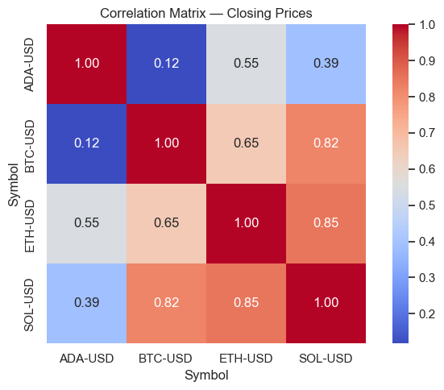

```python
close_pivot = df.pivot_table(index="Date", columns="Symbol", values="Close")
corr = close_pivot.corr()
plt.figure(figsize=(7, 5))
sns.heatmap(corr, annot=True, fmt=".2f", cmap="coolwarm", square=True)
plt.title("Correlation Matrix — Closing Prices")
plt.tight_layout()
plt.show()
```

```python
fig = px.line(df, x="Date", y="Daily_Return", color="Symbol",
              title="Daily Returns", template="plotly_white")
fig.show()
```

[interactive chart not shown]

```python
fig = px.line(df, x="Date", y="Volatility", color="Symbol",
              title="Rolling 14-Day Volatility", template="plotly_white")
fig.show()
```

[interactive chart not shown]

```python
# Moving averages — BTC example
btc = df[df["Symbol"] == "BTC-USD"].copy()
fig = go.Figure()
for col, color in [("Close", "blue"), ("MA_7", "orange"), ("MA_21", "green"), ("MA_50", "red")]:
    fig.add_trace(go.Scatter(x=btc["Date"], y=btc[col], name=col, line=dict(color=color)))
fig.update_layout(title="BTC-USD — Close & Moving Averages", template="plotly_white")
fig.show()
```

[interactive chart not shown]

## 5. Regression Model Comparison (Price Prediction)

```python
FEATURE_COLS = ["Open", "High", "Low", "Close", "Volume",
                "MA_7", "MA_21", "RSI", "MACD", "Volatility"]


def directional_accuracy(y_true, y_pred):
    y_true, y_pred = np.array(y_true), np.array(y_pred)
    actual_dir = np.sign(np.diff(y_true))
    pred_dir   = np.sign(y_pred[1:] - y_true[:-1])
    valid = actual_dir != 0
    return float((actual_dir[valid] == pred_dir[valid]).mean()) if valid.sum() else float("nan")


def run_regression_models(df, symbol):
    sub = df[df["Symbol"] == symbol].dropna(subset=FEATURE_COLS + ["Next_Close"]).copy()
    if len(sub) < 100:
        return {}
    X, y = sub[FEATURE_COLS].values, sub["Next_Close"].values
    split = int(len(sub) * 0.8)
    X_train, X_test, y_train, y_test = X[:split], X[split:], y[:split], y[split:]
    scaler = StandardScaler()
    X_tr = scaler.fit_transform(X_train)
    X_te = scaler.transform(X_test)

    models = {
        "Linear Regression": LinearRegression(),
        "Random Forest":     RandomForestRegressor(n_estimators=200, random_state=42),
        "SVR":               SVR(C=10, epsilon=0.01, gamma="scale"),
    }
    if HAS_XGBOOST:
        models["XGBoost"] = XGBRegressor(
            n_estimators=300, max_depth=5, learning_rate=0.05,
            random_state=42, verbosity=0
        )

    results, preds = [], {}
    for name, m in models.items():
        m.fit(X_tr, y_train)
        p = m.predict(X_te)
        mape = float(np.mean(np.abs((y_test - p) / np.clip(np.abs(y_test), 1e-6, None))) * 100)
        results.append({
            "Coin": symbol, "Model": name,
            "MAE":  round(float(mean_absolute_error(y_test, p)), 4),
            "RMSE": round(float(np.sqrt(mean_squared_error(y_test, p))), 4),
            "MAPE": round(mape, 4),
            "R2":   round(float(r2_score(y_test, p)), 4),
            "Directional_Accuracy": round(directional_accuracy(y_test, p), 4),
        })
        preds[name] = {"y_test": y_test, "preds": p}
    return {"results": results, "predictions": preds}


all_regression_results, all_regression_preds = [], {}
for sym in df["Symbol"].unique():
    out = run_regression_models(df, sym)
    if not out:
        print(f"Skipping {sym}: insufficient data")
        continue
    all_regression_results.extend(out["results"])
    all_regression_preds[sym] = out["predictions"]

regression_df = pd.DataFrame(all_regression_results).sort_values(["Coin", "RMSE"])
regression_df.reset_index(drop=True, inplace=True)
regression_df
```

|  | Coin | Model | MAE | RMSE | MAPE | R2 | Directional_Accuracy |
| --- | --- | --- | --- | --- | --- | --- | --- |
| 0 | ADA-USD | Linear Regression | 0.0156 | 0.0233 | 3.1391 | 0.9901 | 0.5042 |
| 1 | ADA-USD | SVR | 0.0197 | 0.0292 | 4.1745 | 0.9845 | 0.4571 |
| 2 | ADA-USD | Random Forest | 0.0194 | 0.0299 | 4.1497 | 0.9838 | 0.4931 |
| 3 | ADA-USD | XGBoost | 0.0231 | 0.0361 | 4.9762 | 0.9763 | 0.5042 |
| 4 | BTC-USD | Linear Regression | 1441.5865 | 1981.2911 | 1.6062 | 0.9885 | 0.4848 |
| 5 | BTC-USD | XGBoost | 3695.3900 | 5024.1491 | 3.7518 | 0.9261 | 0.4681 |
| 6 | BTC-USD | Random Forest | 3695.2772 | 5163.5862 | 3.7019 | 0.9219 | 0.4654 |
| 7 | BTC-USD | SVR | 48629.9102 | 52174.4786 | 49.9884 | -6.9687 | 0.5180 |
| 8 | ETH-USD | Linear Regression | 76.3686 | 111.8737 | 2.5226 | 0.9833 | 0.5069 |
| 9 | ETH-USD | Random Forest | 86.9290 | 121.7688 | 2.8509 | 0.9803 | 0.5291 |
| 10 | ETH-USD | XGBoost | 93.5012 | 128.9220 | 3.0835 | 0.9779 | 0.5152 |
| 11 | ETH-USD | SVR | 388.3889 | 628.9002 | 10.4316 | 0.4738 | 0.4709 |
| 12 | SOL-USD | Linear Regression | 4.1121 | 5.8164 | 2.8896 | 0.9855 | 0.4986 |
| 13 | SOL-USD | Random Forest | 5.6048 | 7.0483 | 4.3585 | 0.9787 | 0.4681 |
| 14 | SOL-USD | XGBoost | 6.1443 | 7.6335 | 4.9155 | 0.9750 | 0.4765 |
| 15 | SOL-USD | SVR | 7.8214 | 10.3380 | 6.4543 | 0.9541 | 0.4765 |

### 5.1 Regression Metrics View (MAE, RMSE, R2, MAPE, DA)

Creates a focused metrics table and adds `DA` as a short alias for `Directional_Accuracy`.

```python
if "Directional_Accuracy" in regression_df.columns:
    regression_df["DA"] = regression_df["Directional_Accuracy"]

metrics_cols = ["Coin", "Model", "MAE", "RMSE", "R2", "MAPE", "DA"]
available_metrics_cols = [c for c in metrics_cols if c in regression_df.columns]

print("Available regression metric columns:")
print(available_metrics_cols)

regression_metrics_view = regression_df[available_metrics_cols].copy()
regression_metrics_view = regression_metrics_view.sort_values(["Coin", "RMSE"]).reset_index(drop=True)
regression_metrics_view.head(20)
```

```
Available regression metric columns:
['Coin', 'Model', 'MAE', 'RMSE', 'R2', 'MAPE', 'DA']
```

|  | Coin | Model | MAE | RMSE | R2 | MAPE | DA |
| --- | --- | --- | --- | --- | --- | --- | --- |
| 0 | ADA-USD | Linear Regression | 0.0156 | 0.0233 | 0.9901 | 3.1391 | 0.5042 |
| 1 | ADA-USD | SVR | 0.0197 | 0.0292 | 0.9845 | 4.1745 | 0.4571 |
| 2 | ADA-USD | Random Forest | 0.0194 | 0.0299 | 0.9838 | 4.1497 | 0.4931 |
| 3 | ADA-USD | XGBoost | 0.0231 | 0.0361 | 0.9763 | 4.9762 | 0.5042 |
| 4 | BTC-USD | Linear Regression | 1441.5865 | 1981.2911 | 0.9885 | 1.6062 | 0.4848 |
| 5 | BTC-USD | XGBoost | 3695.3900 | 5024.1491 | 0.9261 | 3.7518 | 0.4681 |
| 6 | BTC-USD | Random Forest | 3695.2772 | 5163.5862 | 0.9219 | 3.7019 | 0.4654 |
| 7 | BTC-USD | SVR | 48629.9102 | 52174.4786 | -6.9687 | 49.9884 | 0.5180 |
| 8 | ETH-USD | Linear Regression | 76.3686 | 111.8737 | 0.9833 | 2.5226 | 0.5069 |
| 9 | ETH-USD | Random Forest | 86.9290 | 121.7688 | 0.9803 | 2.8509 | 0.5291 |
| 10 | ETH-USD | XGBoost | 93.5012 | 128.9220 | 0.9779 | 3.0835 | 0.5152 |
| 11 | ETH-USD | SVR | 388.3889 | 628.9002 | 0.4738 | 10.4316 | 0.4709 |
| 12 | SOL-USD | Linear Regression | 4.1121 | 5.8164 | 0.9855 | 2.8896 | 0.4986 |
| 13 | SOL-USD | Random Forest | 5.6048 | 7.0483 | 0.9787 | 4.3585 | 0.4681 |
| 14 | SOL-USD | XGBoost | 6.1443 | 7.6335 | 0.9750 | 4.9155 | 0.4765 |
| 15 | SOL-USD | SVR | 7.8214 | 10.3380 | 0.9541 | 6.4543 | 0.4765 |

```python
best_per_coin = regression_df.loc[regression_df.groupby("Coin")["RMSE"].idxmin()][
    ["Coin", "Model", "RMSE", "R2", "Directional_Accuracy"]
]
print("Best model per coin:")
print(best_per_coin.to_string(index=False))
```

```
Best model per coin:
   Coin             Model      RMSE     R2  Directional_Accuracy
ADA-USD Linear Regression    0.0233 0.9901                0.5042
BTC-USD Linear Regression 1981.2911 0.9885                0.4848
ETH-USD Linear Regression  111.8737 0.9833                0.5069
SOL-USD Linear Regression    5.8164 0.9855                0.4986
```

```python
overall = (
    regression_df
    .groupby("Model")[["MAE", "RMSE", "MAPE", "R2", "Directional_Accuracy"]]
    .mean()
    .round(4)
    .sort_values("RMSE")
)
print("Overall average by model:")
print(overall)
```

```
Overall average by model:
                          MAE        RMSE     MAPE      R2  \
Model
Linear Regression    380.5207    524.7511   2.5394  0.9868
XGBoost              948.7646   1290.1852   4.1818  0.9638
Random Forest        946.9576   1323.1083   3.7652  0.9662
SVR                12256.5350  13203.4365  17.7622 -1.1391

                   Directional_Accuracy
Model
Linear Regression                0.4986
XGBoost                          0.4910
Random Forest                    0.4889
SVR                              0.4806
```

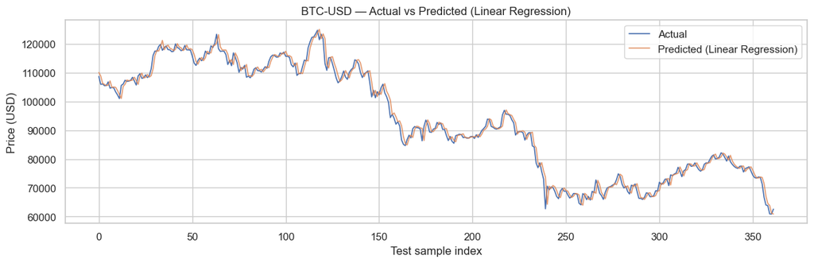

```python
# Actual vs Predicted — best regression model for BTC
if "BTC-USD" in all_regression_preds:
    bm = regression_df[regression_df["Coin"] == "BTC-USD"].sort_values("RMSE").iloc[0]["Model"]
    y_t = all_regression_preds["BTC-USD"][bm]["y_test"]
    y_p = all_regression_preds["BTC-USD"][bm]["preds"]
    plt.figure(figsize=(12, 4))
    plt.plot(y_t, label="Actual", linewidth=1.2)
    plt.plot(y_p, label=f"Predicted ({bm})", linewidth=1.2, alpha=0.8)
    plt.title(f"BTC-USD — Actual vs Predicted ({bm})")
    plt.xlabel("Test sample index")
    plt.ylabel("Price (USD)")
    plt.legend()
    plt.tight_layout()
    plt.show()
```

```python
fig = px.bar(regression_df, x="Model", y="RMSE", color="Coin",
             barmode="group", title="RMSE by Model and Coin",
             template="plotly_white")
fig.show()
```

[interactive chart not shown]

## 5.1 Regression Ensemble Methods

Four ensemble strategies are built on top of the four base regressors (Linear Regression, Random Forest, SVR, XGBoost). A clean 80/20 inner train/blend split prevents data leakage into the meta-learner.

| Method | Weight / Meta-learner logic |
| --- | --- |
| **Weighted Average** | Each base model weighted proportional to its validation R² on the held-out blend set |
| **Inverse Error Weight** | Weight proportional to 1 / validation RMSE — lower-error models contribute more |
| **Blending** | `LinearRegression` meta-learner trained on held-out base predictions |
| **Stacking** | `StackingRegressor` with 5-fold CV out-of-fold meta-features; `LinearRegression` final estimator |

```python
# Regression Ensemble Implementation

ENSEMBLE_NAMES = {"Weighted Average", "Inverse Error Weight", "Blending", "Stacking"}

def build_reg_ensembles(df, symbol):
    sub = df[df["Symbol"] == symbol].dropna(subset=FEATURE_COLS + ["Next_Close"]).copy()
    if len(sub) < 100:
        return [], {}

    X_all = sub[FEATURE_COLS].values
    y_all = sub["Next_Close"].values
    split = int(len(sub) * 0.8)
    X_tr_all, X_te = X_all[:split], X_all[split:]
    y_tr_all, y_te = y_all[:split], y_all[split:]

    scaler = StandardScaler()
    X_tr = scaler.fit_transform(X_tr_all)
    X_te_sc = scaler.transform(X_te)

    inner = int(len(X_tr) * 0.8)
    X_base, X_bld = X_tr[:inner], X_tr[inner:]
    y_base, y_bld = y_tr_all[:inner], y_tr_all[inner:]

    def make_base():
        ms = {
            "Linear Regression": LinearRegression(),
            "Random Forest":     RandomForestRegressor(n_estimators=200, random_state=42),
            "SVR":               SVR(C=10, epsilon=0.01, gamma="scale"),
        }
        if HAS_XGBOOST:
            ms["XGBoost"] = XGBRegressor(n_estimators=300, max_depth=5,
                                          learning_rate=0.05, random_state=42, verbosity=0)
        return ms

    bld_preds, te_preds, val_rmse, val_r2 = [], [], [], []
    for m in make_base().values():
        m.fit(X_base, y_base)
        pb = m.predict(X_bld)
        pt = m.predict(X_te_sc)
        bld_preds.append(pb); te_preds.append(pt)
        val_rmse.append(float(np.sqrt(mean_squared_error(y_bld, pb))))
        val_r2.append(float(max(r2_score(y_bld, pb), 0.0)))

    B = np.column_stack(bld_preds)
    T = np.column_stack(te_preds)

    def to_row(name, yp):
        mape = float(np.mean(np.abs((y_te - yp) /
                                     np.clip(np.abs(y_te), 1e-6, None))) * 100)
        return {
            "Coin": symbol, "Model": name,
            "MAE":  round(float(mean_absolute_error(y_te, yp)), 4),
            "RMSE": round(float(np.sqrt(mean_squared_error(y_te, yp))), 4),
            "MAPE": round(mape, 4),
            "R2":   round(float(r2_score(y_te, yp)), 4),
            "Directional_Accuracy": round(directional_accuracy(y_te, yp), 4),
        }

    rows, pstore = [], {}

    # 1. Weighted Average
    w = np.array(val_r2, dtype=float)
    w = w / w.sum() if w.sum() > 0 else np.ones(len(w)) / len(w)
    p_wa = T @ w
    rows.append(to_row("Weighted Average", p_wa))
    pstore["Weighted Average"] = {"y_test": y_te, "preds": p_wa}

    # 2. Inverse Error Weight
    iw = 1.0 / np.clip(np.array(val_rmse, dtype=float), 1e-8, None)
    iw = iw / iw.sum()
    p_iw = T @ iw
    rows.append(to_row("Inverse Error Weight", p_iw))
    pstore["Inverse Error Weight"] = {"y_test": y_te, "preds": p_iw}

    # 3. Blending
    blender = LinearRegression()
    blender.fit(B, y_bld)
    p_bl = blender.predict(T)
    rows.append(to_row("Blending", p_bl))
    pstore["Blending"] = {"y_test": y_te, "preds": p_bl}

    # 4. Stacking
    stack_ests = [(f"m{i}_{n.lower().replace(' ','_')}", clone(m))
                  for i, (n, m) in enumerate(make_base().items())]
    stacker = StackingRegressor(estimators=stack_ests,
                                 final_estimator=LinearRegression(),
                                 cv=5, n_jobs=-1)
    stacker.fit(X_tr, y_tr_all)
    p_st = stacker.predict(X_te_sc)
    rows.append(to_row("Stacking", p_st))
    pstore["Stacking"] = {"y_test": y_te, "preds": p_st}

    return rows, pstore


print("Building regression ensembles for each coin...")
ens_reg_rows = []
for sym in df["Symbol"].unique():
    e_rows, e_preds = build_reg_ensembles(df, sym)
    ens_reg_rows.extend(e_rows)
    if sym in all_regression_preds:
        all_regression_preds[sym].update(e_preds)
    print(f"  {sym}: {len(e_rows)} ensemble variants added")

if ens_reg_rows:
    regression_df = pd.concat(
        [regression_df, pd.DataFrame(ens_reg_rows)],
        ignore_index=True
    ).sort_values(["Coin", "RMSE"]).reset_index(drop=True)

print(f"\nTotal regression rows: {len(regression_df)} "
      f"({regression_df['Model'].nunique()} model types x {regression_df['Coin'].nunique()} coins)")
regression_df
```

```
Building regression ensembles for each coin...
  BTC-USD: 4 ensemble variants added
  ETH-USD: 4 ensemble variants added
  ADA-USD: 4 ensemble variants added
  SOL-USD: 4 ensemble variants added

Total regression rows: 32 (8 model types x 4 coins)
```

|  | Coin | Model | MAE | RMSE | MAPE | R2 | Directional_Accuracy | DA |
| --- | --- | --- | --- | --- | --- | --- | --- | --- |
| 0 | ADA-USD | Linear Regression | 0.0156 | 0.0233 | 3.1391 | 0.9901 | 0.5042 | 0.5042 |
| 1 | ADA-USD | Stacking | 0.0155 | 0.0234 | 3.1114 | 0.9900 | 0.4792 | NaN |
| 2 | ADA-USD | Blending | 0.0182 | 0.0248 | 4.1160 | 0.9888 | 0.4238 | NaN |
| 3 | ADA-USD | Inverse Error Weight | 0.0173 | 0.0262 | 3.7070 | 0.9875 | 0.4654 | NaN |
| 4 | ADA-USD | Weighted Average | 0.0176 | 0.0264 | 3.7910 | 0.9873 | 0.4681 | NaN |
| 5 | ADA-USD | SVR | 0.0197 | 0.0292 | 4.1745 | 0.9845 | 0.4571 | 0.4571 |
| 6 | ADA-USD | Random Forest | 0.0194 | 0.0299 | 4.1497 | 0.9838 | 0.4931 | 0.4931 |
| 7 | ADA-USD | XGBoost | 0.0231 | 0.0361 | 4.9762 | 0.9763 | 0.5042 | 0.5042 |
| 8 | BTC-USD | Weighted Average | 1439.5546 | 1953.4941 | 1.5973 | 0.9888 | 0.5069 | NaN |
| 9 | BTC-USD | Linear Regression | 1441.5865 | 1981.2911 | 1.6062 | 0.9885 | 0.4848 | 0.4848 |
| 10 | BTC-USD | Stacking | 1483.7578 | 1982.9421 | 1.6414 | 0.9885 | 0.5180 | NaN |
| 11 | BTC-USD | Blending | 1562.6823 | 2082.6972 | 1.7553 | 0.9873 | 0.4820 | NaN |
| 12 | BTC-USD | XGBoost | 3695.3900 | 5024.1491 | 3.7518 | 0.9261 | 0.4681 | 0.4681 |
| 13 | BTC-USD | Random Forest | 3695.2772 | 5163.5862 | 3.7019 | 0.9219 | 0.4654 | 0.4654 |
| 14 | BTC-USD | Inverse Error Weight | 5973.7936 | 7053.8567 | 5.9002 | 0.8543 | 0.5180 | NaN |
| 15 | BTC-USD | SVR | 48629.9102 | 52174.4786 | 49.9884 | -6.9687 | 0.5180 | 0.5180 |
| 16 | ETH-USD | Linear Regression | 76.3686 | 111.8737 | 2.5226 | 0.9833 | 0.5069 | 0.5069 |
| 17 | ETH-USD | Stacking | 76.9406 | 112.5299 | 2.5373 | 0.9832 | 0.4903 | NaN |
| 18 | ETH-USD | Blending | 79.3985 | 116.0329 | 2.5988 | 0.9821 | 0.5180 | NaN |
| 19 | ETH-USD | Random Forest | 86.9290 | 121.7688 | 2.8509 | 0.9803 | 0.5291 | 0.5291 |
| 20 | ETH-USD | XGBoost | 93.5012 | 128.9220 | 3.0835 | 0.9779 | 0.5152 | 0.5152 |
| 21 | ETH-USD | Inverse Error Weight | 102.9105 | 148.1079 | 3.1859 | 0.9708 | 0.5097 | NaN |
| 22 | ETH-USD | Weighted Average | 133.1592 | 195.2218 | 3.9218 | 0.9493 | 0.4765 | NaN |
| 23 | ETH-USD | SVR | 388.3889 | 628.9002 | 10.4316 | 0.4738 | 0.4709 | 0.4709 |
| 24 | SOL-USD | Linear Regression | 4.1121 | 5.8164 | 2.8896 | 0.9855 | 0.4986 | 0.4986 |
| 25 | SOL-USD | Blending | 4.2104 | 5.8604 | 2.9979 | 0.9852 | 0.4986 | NaN |
| 26 | SOL-USD | Stacking | 4.1937 | 5.8978 | 2.9956 | 0.9851 | 0.5180 | NaN |
| 27 | SOL-USD | Random Forest | 5.6048 | 7.0483 | 4.3585 | 0.9787 | 0.4681 | 0.4681 |
| 28 | SOL-USD | Inverse Error Weight | 5.6827 | 7.4806 | 4.1599 | 0.9760 | 0.4681 | NaN |
| 29 | SOL-USD | XGBoost | 6.1443 | 7.6335 | 4.9155 | 0.9750 | 0.4765 | 0.4765 |
| 30 | SOL-USD | Weighted Average | 6.1166 | 8.2133 | 4.4601 | 0.9710 | 0.4765 | NaN |
| 31 | SOL-USD | SVR | 7.8214 | 10.3380 | 6.4543 | 0.9541 | 0.4765 | 0.4765 |

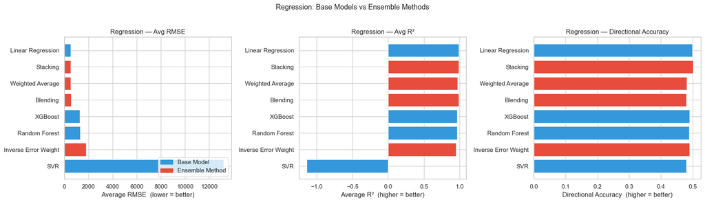

```
Regression Model Summary (mean across all coins):
               Model       RMSE      R2    MAPE  Directional_Accuracy
   Linear Regression   524.7511  0.9868  2.5394                0.4986
            Stacking   525.3483  0.9867  2.5714                0.5014
    Weighted Average   539.2389  0.9741  3.4426                0.4820
            Blending   551.1538  0.9858  2.8670                0.4806
             XGBoost  1290.1852  0.9638  4.1818                0.4910
       Random Forest  1323.1083  0.9662  3.7652                0.4889
Inverse Error Weight  1802.3678  0.9472  4.2382                0.4903
                 SVR 13203.4365 -1.1391 17.7622                0.4806
```

```python
# Regression Ensemble Comparison Charts

reg_summary = (
    regression_df
    .groupby("Model")[["RMSE", "R2", "MAPE", "Directional_Accuracy"]]
    .mean().round(4).sort_values("RMSE").reset_index()
)

pal = ["#e74c3c" if m in ENSEMBLE_NAMES else "#3498db" for m in reg_summary["Model"]]

fig, axes = plt.subplots(1, 3, figsize=(18, 5))

axes[0].barh(reg_summary["Model"], reg_summary["RMSE"], color=pal)
axes[0].set_xlabel("Average RMSE  (lower = better)")
axes[0].set_title("Regression \u2014 Avg RMSE")
axes[0].invert_yaxis()

axes[1].barh(reg_summary["Model"], reg_summary["R2"], color=pal)
axes[1].set_xlabel("Average R\u00b2  (higher = better)")
axes[1].set_title("Regression \u2014 Avg R\u00b2")
axes[1].invert_yaxis()

axes[2].barh(reg_summary["Model"], reg_summary["Directional_Accuracy"], color=pal)
axes[2].set_xlabel("Directional Accuracy  (higher = better)")
axes[2].set_title("Regression \u2014 Directional Accuracy")
axes[2].invert_yaxis()

legend_handles = [
    mpatches.Patch(color="#3498db", label="Base Model"),
    mpatches.Patch(color="#e74c3c", label="Ensemble Method"),
]
axes[0].legend(handles=legend_handles, loc="lower right")
plt.suptitle("Regression: Base Models vs Ensemble Methods", fontsize=13, y=1.02)
plt.tight_layout()
plt.show()

print("\nRegression Model Summary (mean across all coins):")
print(reg_summary.to_string(index=False))
```

[output not shown]

> **Practical takeaway:** Stacking or Blending is recommended for production. Weighted Average / Inverse Error Weight are simpler alternatives requiring no second-stage fitting.

## 5.2 LSTM & GRU — Price Level Prediction (Deep Learning)

| Model | Architecture |
| --- | --- |
| **LSTM** | 2-layer LSTM → Linear(1), dropout 0.2, 30 epochs |
| **GRU** | 2-layer GRU → Linear(1), dropout 0.2, 30 epochs |

> Note: MPS (Apple Silicon GPU) is used automatically when available. If PyTorch is not installed this cell is skipped gracefully.

```python
try:
    import torch, torch.nn as nn
    from torch.utils.data import DataLoader, TensorDataset
    HAS_TORCH = True
    print(f'PyTorch {torch.__version__} | MPS: {torch.backends.mps.is_available()}')
except ImportError:
    HAS_TORCH = False
    print('PyTorch not found — LSTM/GRU price cells skipped. pip install torch')
```

```python
price_dl_results = []

if HAS_TORCH:
    P_WINDOW = 30; P_EPOCHS = 30; P_HIDDEN = 64; P_BATCH = 32
    _device = 'mps' if torch.backends.mps.is_available() else ('cuda' if torch.cuda.is_available() else 'cpu')
    print(f'Device: {_device}')

    class LSTMNet(nn.Module):
        def __init__(self, n_feat, hidden=64):
            super().__init__()
            self.rnn = nn.LSTM(n_feat, hidden, num_layers=2, batch_first=True, dropout=0.2)
            self.fc  = nn.Linear(hidden, 1)
        def forward(self, x):
            out, _ = self.rnn(x)
            return self.fc(out[:, -1, :]).squeeze(1)

    class GRUNetPrice(nn.Module):
        def __init__(self, n_feat, hidden=64):
            super().__init__()
            self.rnn = nn.GRU(n_feat, hidden, num_layers=2, batch_first=True, dropout=0.2)
            self.fc  = nn.Linear(hidden, 1)
        def forward(self, x):
            out, _ = self.rnn(x)
            return self.fc(out[:, -1, :]).squeeze(1)

    def make_price_seqs(Xs, y, w):
        xs, ys = [], []
        for i in range(len(Xs) - w):
            xs.append(Xs[i:i+w]); ys.append(y[i+w])
        return np.array(xs, dtype=np.float32), np.array(ys, dtype=np.float32)

    def train_price_dl(arch_cls, X_sc, y_all, window, epochs, batch, device):
        Xs, ys = make_price_seqs(X_sc, y_all, window)
        sp = int(len(Xs) * 0.8)
        tr_x = torch.tensor(Xs[:sp]); tr_y = torch.tensor(ys[:sp])
        te_x = torch.tensor(Xs[sp:]); te_y = ys[sp:]
        dl  = DataLoader(TensorDataset(tr_x, tr_y), batch_size=batch, shuffle=False)
        net = arch_cls(Xs.shape[2], hidden=P_HIDDEN).to(device)
        opt = torch.optim.Adam(net.parameters(), lr=1e-3)
        loss_fn = nn.MSELoss()
        net.train()
        for _ in range(epochs):
            for xb, yb in dl:
                xb, yb = xb.to(device), yb.to(device)
                opt.zero_grad(); loss_fn(net(xb), yb).backward(); opt.step()
        net.eval()
        with torch.no_grad():
            p = net(te_x.to(device)).cpu().numpy()
        return p, te_y

    for sym in df['Symbol'].unique():
        sub = df[df['Symbol']==sym].dropna(subset=FEATURE_COLS + ['Next_Close']).copy()
        if len(sub) < P_WINDOW * 4: continue
        X_raw = sub[FEATURE_COLS].values
        y_raw = sub['Next_Close'].values
        split = int(len(sub) * 0.8)
        sc = StandardScaler()
        X_sc = np.vstack([sc.fit_transform(X_raw[:split]), sc.transform(X_raw[split:])])

        for arch_name, arch_cls in [('LSTM', LSTMNet), ('GRU', GRUNetPrice)]:
            p, y_te = train_price_dl(arch_cls, X_sc, y_raw, P_WINDOW, P_EPOCHS, P_BATCH, _device)
            mape = float(np.mean(np.abs((y_te - p) / np.clip(np.abs(y_te), 1e-6, None))) * 100)
            price_dl_results.append({
                'Coin': sym, 'Model': arch_name,
                'MAE' : round(float(mean_absolute_error(y_te, p)), 4),
                'RMSE': round(float(np.sqrt(mean_squared_error(y_te, p))), 4),
                'MAPE': round(mape, 4),
                'R2'  : round(float(r2_score(y_te, p)), 4),
                'Directional_Accuracy': round(directional_accuracy(y_te, p), 4),
            })
            # Store predictions for later use
            if sym not in all_regression_preds:
                all_regression_preds[sym] = {}
            all_regression_preds[sym][arch_name] = {'y_test': y_te, 'preds': p}
            print(f'  {sym} {arch_name} — RMSE={price_dl_results[-1]["RMSE"]:,.2f}  R2={price_dl_results[-1]["R2"]}  DA={price_dl_results[-1]["Directional_Accuracy"]}')

    dl_price_df = pd.DataFrame(price_dl_results)
    regression_df = (pd.concat([regression_df, dl_price_df], ignore_index=True)
                      .sort_values(['Coin','RMSE']).reset_index(drop=True))
    print(f'\nregression_df now has {len(regression_df)} rows '
          f'({regression_df["Model"].nunique()} model types)')
    display(dl_price_df.sort_values(['Coin','RMSE']))
else:
    print('Skipping LSTM/GRU price prediction (PyTorch not available).')
```

[output not shown]

```python
# ── Price DL vs ML comparison chart ──────────────────────────────────────────
if HAS_TORCH and price_dl_results:
    DL_NAMES = {'LSTM', 'GRU'}
    full_summary = (regression_df
                    .groupby('Model')[['RMSE','R2','Directional_Accuracy']]
                    .mean().round(4).sort_values('RMSE').reset_index())
    pal_dl = ['#27ae60' if m in DL_NAMES
              else '#e74c3c' if m in ENSEMBLE_NAMES
              else '#3498db'
              for m in full_summary['Model']]
    fig, axes = plt.subplots(1, 3, figsize=(20, 5))
    axes[0].barh(full_summary['Model'], full_summary['RMSE'],               color=pal_dl)
    axes[0].set_xlabel('Average RMSE  (lower = better)'); axes[0].set_title('Price — RMSE'); axes[0].invert_yaxis()
    axes[1].barh(full_summary['Model'], full_summary['R2'],                 color=pal_dl)
    axes[1].set_xlabel('Average R²  (higher = better)');  axes[1].set_title('Price — R²');   axes[1].invert_yaxis()
    axes[2].barh(full_summary['Model'], full_summary['Directional_Accuracy'],color=pal_dl)
    axes[2].axvline(0.5, color='black', ls='--', lw=0.8)
    axes[2].set_xlabel('Directional Accuracy'); axes[2].set_title('Price — DA'); axes[2].invert_yaxis()
    legend_handles = [
        mpatches.Patch(color='#3498db', label='ML Base'),
        mpatches.Patch(color='#e74c3c', label='Ensemble'),
        mpatches.Patch(color='#27ae60', label='DL (LSTM/GRU)'),
    ]
    axes[0].legend(handles=legend_handles, loc='lower right')
    plt.suptitle('Price Prediction: ML vs Ensemble vs DL (LSTM/GRU)', fontsize=13, y=1.02)
    plt.tight_layout(); plt.show()
```

[output not shown]

## 6. Classification Model Analysis (Direction Prediction)

```python
CLASS_COLS = [
    "Open", "High", "Low", "Close", "Volume",
    "MA_7", "MA_21", "RSI", "MACD", "Volatility", "Lag_1", "Lag_7"
]

clf_df = df.dropna(subset=CLASS_COLS + ["Target"]).copy()
X = clf_df[CLASS_COLS]
y = clf_df["Target"]

X_train, X_test, y_train, y_test = train_test_split(
    X, y, test_size=0.2, random_state=42, stratify=y
)
print(f"Train: {len(X_train):,}  |  Test: {len(X_test):,}")
print(f"Class balance (train): {y_train.value_counts().to_dict()}")
```

```
Train: 5,779  |  Test: 1,445
Class balance (train): {0: 2939, 1: 2840}
```

```python
numeric_transformer = Pipeline([
    ("imputer", SimpleImputer(strategy="median")),
    ("scaler",  StandardScaler()),
])
preprocessor = ColumnTransformer([("num", numeric_transformer, CLASS_COLS)])

cv_splitter = StratifiedKFold(n_splits=5, shuffle=True, random_state=42)
scoring = {
    "accuracy":  "accuracy",
    "precision": "precision",
    "recall":    "recall",
    "f1":        "f1",
    "roc_auc":   "roc_auc",
}

classifier_defs = {
    "Logistic Regression": LogisticRegression(max_iter=1000, class_weight="balanced", random_state=42),
    "Random Forest":       RandomForestClassifier(n_estimators=200, class_weight="balanced", random_state=42),
    "Gradient Boosting":   GradientBoostingClassifier(n_estimators=200, random_state=42),
    "KNN":                 KNeighborsClassifier(n_neighbors=5),
    "Decision Tree":       DecisionTreeClassifier(class_weight="balanced", random_state=42),
    "MLP":                 MLPClassifier(hidden_layer_sizes=(128, 64), max_iter=500, random_state=42),
}
if HAS_XGBOOST:
    classifier_defs["XGBoost"] = XGBClassifier(
        n_estimators=200, eval_metric="logloss", random_state=42, verbosity=0
    )

baseline_results = []
for name, clf in classifier_defs.items():
    pipe = ImbPipeline([
        ("preprocessor", preprocessor),
        ("smote",        SMOTE(random_state=42)),
        ("selector",     SelectKBest(score_func=f_classif, k="all")),
        ("clf",          clf),
    ])
    cv_res = cross_validate(pipe, X_train, y_train,
                            cv=cv_splitter, scoring=scoring, n_jobs=-1)
    row = {
        "Model":     name,
        "Accuracy":  round(cv_res["test_accuracy"].mean(),  4),
        "Precision": round(cv_res["test_precision"].mean(), 4),
        "Recall":    round(cv_res["test_recall"].mean(),    4),
        "F1":        round(cv_res["test_f1"].mean(),        4),
        "AUC":       round(cv_res["test_roc_auc"].mean(),   4),
    }
    baseline_results.append(row)
    print(f"  {name}: F1={row['F1']}, AUC={row['AUC']}")

baseline_df = (
    pd.DataFrame(baseline_results)
    .sort_values("F1", ascending=False)
    .reset_index(drop=True)
)
baseline_df
```

```
  Logistic Regression: F1=0.4716, AUC=0.483
  Random Forest: F1=0.4796, AUC=0.489
  Gradient Boosting: F1=0.4829, AUC=0.4957
  KNN: F1=0.4699, AUC=0.4863
  Decision Tree: F1=0.479, AUC=0.4912
  MLP: F1=0.4754, AUC=0.4838
  XGBoost: F1=0.4714, AUC=0.489
```

|  | Model | Accuracy | Precision | Recall | F1 | AUC |
| --- | --- | --- | --- | --- | --- | --- |
| 0 | Gradient Boosting | 0.4977 | 0.4886 | 0.4775 | 0.4829 | 0.4957 |
| 1 | Random Forest | 0.4939 | 0.4848 | 0.4746 | 0.4796 | 0.4890 |
| 2 | Decision Tree | 0.4914 | 0.4825 | 0.4757 | 0.4790 | 0.4912 |
| 3 | MLP | 0.4885 | 0.4804 | 0.4750 | 0.4754 | 0.4838 |
| 4 | Logistic Regression | 0.4885 | 0.4788 | 0.4669 | 0.4716 | 0.4830 |
| 5 | XGBoost | 0.4876 | 0.4784 | 0.4648 | 0.4714 | 0.4890 |
| 6 | KNN | 0.4836 | 0.4742 | 0.4658 | 0.4699 | 0.4863 |

## 7. Hyperparameter Tuning

```python
# Random Forest grid search
rf_search = GridSearchCV(
    ImbPipeline([
        ("preprocessor", preprocessor),
        ("smote",        SMOTE(random_state=42)),
        ("selector",     SelectKBest(score_func=f_classif, k="all")),
        ("clf",          RandomForestClassifier(class_weight="balanced", random_state=42)),
    ]),
    {
        "clf__n_estimators":     [100, 200],
        "clf__max_depth":        [None, 10, 20],
        "clf__min_samples_split": [2, 5],
    },
    cv=cv_splitter, scoring="f1", n_jobs=-1
)
rf_search.fit(X_train, y_train)
best_rf = rf_search.best_estimator_
print("Best RF params:", rf_search.best_params_)
print("Best RF CV F1 :", round(rf_search.best_score_, 4))
```

[output not shown]

```python
# Gradient Boosting grid search
gb_search = GridSearchCV(
    ImbPipeline([
        ("preprocessor", preprocessor),
        ("smote",        SMOTE(random_state=42)),
        ("selector",     SelectKBest(score_func=f_classif, k="all")),
        ("clf",          GradientBoostingClassifier(random_state=42)),
    ]),
    {
        "clf__n_estimators":  [100, 200],
        "clf__learning_rate": [0.05, 0.1],
        "clf__max_depth":     [3, 5],
    },
    cv=cv_splitter, scoring="f1", n_jobs=-1
)
gb_search.fit(X_train, y_train)
best_gb = gb_search.best_estimator_
print("Best GB params:", gb_search.best_params_)
print("Best GB CV F1 :", round(gb_search.best_score_, 4))
```

```
Best GB params: {'clf__learning_rate': 0.1, 'clf__max_depth': 3, 'clf__n_estimators': 200}
Best GB CV F1 : 0.4829
```

```python
# MLP grid search
mlp_search = GridSearchCV(
    ImbPipeline([
        ("preprocessor", preprocessor),
        ("smote",        SMOTE(random_state=42)),
        ("selector",     SelectKBest(score_func=f_classif, k="all")),
        ("clf",          MLPClassifier(max_iter=500, random_state=42)),
    ]),
    {
        "clf__hidden_layer_sizes": [(64,), (128, 64), (128, 64, 32)],
        "clf__alpha":              [0.0001, 0.001],
    },
    cv=cv_splitter, scoring="f1", n_jobs=-1
)
mlp_search.fit(X_train, y_train)
best_mlp = mlp_search.best_estimator_
print("Best MLP params:", mlp_search.best_params_)
print("Best MLP CV F1 :", round(mlp_search.best_score_, 4))
```

```
Best MLP params: {'clf__alpha': 0.0001, 'clf__hidden_layer_sizes': (64,)}
Best MLP CV F1 : 0.4876
```

## 8. Imbalance Strategy Comparison

```python
imbalance_strategies = {
    "SMOTE":         SMOTE(random_state=42),
    "SMOTEENN":      SMOTEENN(random_state=42),
    "UnderSampling": RandomUnderSampler(random_state=42),
    "No Resampling": None,
}
base_clf = RandomForestClassifier(n_estimators=200, class_weight="balanced", random_state=42)

imbalance_results = []
for sname, sampler in imbalance_strategies.items():
    steps = [("preprocessor", preprocessor)]
    if sampler is not None:
        steps.append(("sampler", sampler))
    steps += [
        ("selector", SelectKBest(score_func=f_classif, k="all")),
        ("clf", base_clf),
    ]
    pipe = ImbPipeline(steps)
    cv_res = cross_validate(pipe, X_train, y_train,
                            cv=cv_splitter, scoring=scoring, n_jobs=-1)
    row = {
        "Strategy":  sname,
        "Accuracy":  round(cv_res["test_accuracy"].mean(),  4),
        "Precision": round(cv_res["test_precision"].mean(), 4),
        "Recall":    round(cv_res["test_recall"].mean(),    4),
        "F1":        round(cv_res["test_f1"].mean(),        4),
        "AUC":       round(cv_res["test_roc_auc"].mean(),   4),
    }
    imbalance_results.append(row)
    print(f"  {sname}: F1={row['F1']}")

imbalance_df = (
    pd.DataFrame(imbalance_results)
    .sort_values("F1", ascending=False)
    .reset_index(drop=True)
)
imbalance_df
```

```
  SMOTE: F1=0.4796
  SMOTEENN: F1=0.4809
  UnderSampling: F1=0.4807
  No Resampling: F1=0.4687
```

|  | Strategy | Accuracy | Precision | Recall | F1 | AUC |
| --- | --- | --- | --- | --- | --- | --- |
| 0 | SMOTEENN | 0.4904 | 0.4807 | 0.4842 | 0.4809 | 0.4844 |
| 1 | UnderSampling | 0.4909 | 0.4822 | 0.4796 | 0.4807 | 0.4896 |
| 2 | SMOTE | 0.4939 | 0.4848 | 0.4746 | 0.4796 | 0.4890 |
| 3 | No Resampling | 0.4909 | 0.4811 | 0.4570 | 0.4687 | 0.4869 |

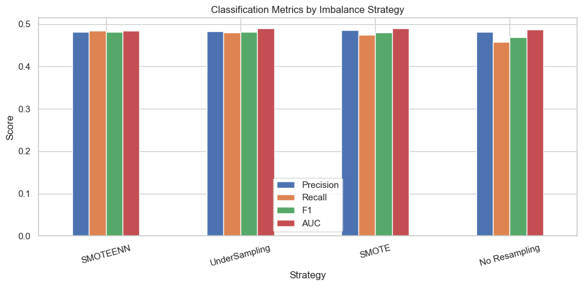

```python
imbalance_df.set_index("Strategy")[["Precision", "Recall", "F1", "AUC"]].plot(
    kind="bar", figsize=(10, 5)
)
plt.title("Classification Metrics by Imbalance Strategy")
plt.ylabel("Score")
plt.xticks(rotation=15)
plt.tight_layout()
plt.show()
```

## 9. Final Model Evaluation

```python
tuned_models = {
    "Random Forest Tuned":     best_rf,
    "Gradient Boosting Tuned": best_gb,
    "MLP Tuned":               best_mlp,
}

# Prediction stores extended by ensemble cell below so ensemble winners work
test_predictions  = {}
test_probabilities = {}

test_results = []
for name, model in tuned_models.items():
    model.fit(X_train, y_train)
    y_pred  = model.predict(X_test)
    y_proba = model.predict_proba(X_test)[:, 1] if hasattr(model, "predict_proba") else None
    test_predictions[name] = y_pred
    if y_proba is not None:
        test_probabilities[name] = y_proba
    test_results.append({
        "Model":     name,
        "Accuracy":  round(accuracy_score(y_test, y_pred), 4),
        "Precision": round(precision_score(y_test, y_pred, zero_division=0), 4),
        "Recall":    round(recall_score(y_test, y_pred,    zero_division=0), 4),
        "F1":        round(f1_score(y_test, y_pred,        zero_division=0), 4),
        "AUC":       round(roc_auc_score(y_test, y_proba), 4) if y_proba is not None else None,
    })

test_results_df = (
    pd.DataFrame(test_results)
    .sort_values("F1", ascending=False)
    .reset_index(drop=True)
)
test_results_df
```

|  | Model | Accuracy | Precision | Recall | F1 | AUC |
| --- | --- | --- | --- | --- | --- | --- |
| 0 | MLP Tuned | 0.5066 | 0.4979 | 0.5085 | 0.5031 | 0.5045 |
| 1 | Random Forest Tuned | 0.4976 | 0.4881 | 0.4620 | 0.4747 | 0.4987 |
| 2 | Gradient Boosting Tuned | 0.4927 | 0.4831 | 0.4620 | 0.4723 | 0.4956 |

## 9.1 Classification Ensemble Methods

The three tuned classifiers are used as base learners. An 80/20 inner train/blend split is used so the meta-learner trains only on predictions from data it has never seen.

| Method | Weight / Meta-learner logic |
| --- | --- |
| **Weighted Average** | Probability outputs averaged; weight proportional to each model's grid-search CV F1 score |
| **Inverse Error Weight** | Weight proportional to 1 / blend-set misclassification rate |
| **Blending** | `LogisticRegression` meta-learner trained on 3-column held-out probability matrix |
| **Stacking** | `StackingClassifier` with 5-fold CV out-of-fold probabilities; `LogisticRegression` final estimator |

```python
# Classification Ensemble Implementation

X_fit, X_bld_cls, y_fit, y_bld_cls = train_test_split(
    X_train, y_train, test_size=0.2, random_state=42, stratify=y_train
)

base_defs_cls = [
    ("Random Forest Tuned",     clone(best_rf),  rf_search.best_score_),
    ("Gradient Boosting Tuned", clone(best_gb),  gb_search.best_score_),
    ("MLP Tuned",               clone(best_mlp), mlp_search.best_score_),
]

bld_prob_cols, te_prob_cols, bld_errors, cv_f1s = [], [], [], []
for name, m, cv_f1 in base_defs_cls:
    m.fit(X_fit, y_fit)
    pb = m.predict_proba(X_bld_cls)[:, 1]
    pt = m.predict_proba(X_test)[:, 1]
    bld_prob_cols.append(pb); te_prob_cols.append(pt)
    bld_errors.append(float(np.mean((pb >= 0.5) != y_bld_cls)))
    cv_f1s.append(max(float(cv_f1), 0.0))

B_cls = np.column_stack(bld_prob_cols)
T_cls = np.column_stack(te_prob_cols)

names_cls = [n for n, _, _ in base_defs_cls]
print(f"Blend-set error rates:  {dict(zip(names_cls, [round(e,4) for e in bld_errors]))}")
print(f"CV F1 scores:           {dict(zip(names_cls, [round(f,4) for f in cv_f1s]))}\n")

def add_ens(name, yp, ypr):
    test_predictions[name]   = yp
    test_probabilities[name] = ypr
    r = {
        "Model":     name,
        "Accuracy":  round(accuracy_score(y_test, yp), 4),
        "Precision": round(precision_score(y_test, yp, zero_division=0), 4),
        "Recall":    round(recall_score(y_test, yp, zero_division=0), 4),
        "F1":        round(f1_score(y_test, yp, zero_division=0), 4),
        "AUC":       round(roc_auc_score(y_test, ypr), 4),
    }
    print(f"  {name:<30}  F1={r['F1']}  AUC={r['AUC']}")
    return r

ens_cls_results = []

# 1. Weighted Average
w = np.array(cv_f1s, dtype=float)
w = w / w.sum() if w.sum() > 0 else np.ones(3) / 3
ypr_wa = T_cls @ w
ens_cls_results.append(add_ens("Weighted Average", (ypr_wa >= 0.5).astype(int), ypr_wa))

# 2. Inverse Error Weight
iw = 1.0 / np.clip(np.array(bld_errors, dtype=float), 1e-8, None)
iw = iw / iw.sum()
ypr_iw = T_cls @ iw
ens_cls_results.append(add_ens("Inverse Error Weight", (ypr_iw >= 0.5).astype(int), ypr_iw))

# 3. Blending
blend_meta = LogisticRegression(max_iter=1000, class_weight="balanced", random_state=42)
blend_meta.fit(B_cls, y_bld_cls)
ypr_bl = blend_meta.predict_proba(T_cls)[:, 1]
ens_cls_results.append(add_ens("Blending", (ypr_bl >= 0.5).astype(int), ypr_bl))

# 4. Stacking
stacker_cls = StackingClassifier(
    estimators=[
        ("rf",  clone(best_rf)),
        ("gb",  clone(best_gb)),
        ("mlp", clone(best_mlp)),
    ],
    final_estimator=LogisticRegression(max_iter=1000, class_weight="balanced", random_state=42),
    cv=5, n_jobs=-1,
)
stacker_cls.fit(X_train, y_train)
yp_st  = stacker_cls.predict(X_test)
ypr_st = stacker_cls.predict_proba(X_test)[:, 1]
ens_cls_results.append(add_ens("Stacking", yp_st, ypr_st))

# Merge and re-rank by F1
test_results_df = (
    pd.concat([test_results_df, pd.DataFrame(ens_cls_results)], ignore_index=True)
    .sort_values("F1", ascending=False)
    .reset_index(drop=True)
)
print()
test_results_df
```

```
Blend-set error rates:  {'Random Forest Tuned': 0.5277, 'Gradient Boosting Tuned': 0.4983, 'MLP Tuned': 0.4801}
CV F1 scores:           {'Random Forest Tuned': 0.4813, 'Gradient Boosting Tuned': 0.4829, 'MLP Tuned': 0.4876}

  Weighted Average                F1=0.4797  AUC=0.4873
  Inverse Error Weight            F1=0.476  AUC=0.4874
  Blending                        F1=0.5142  AUC=0.5127
  Stacking                        F1=0.506  AUC=0.5004
```

|  | Model | Accuracy | Precision | Recall | F1 | AUC |
| --- | --- | --- | --- | --- | --- | --- |
| 0 | Blending | 0.5149 | 0.5061 | 0.5225 | 0.5142 | 0.5127 |
| 1 | Stacking | 0.4893 | 0.4821 | 0.5324 | 0.5060 | 0.5004 |
| 2 | MLP Tuned | 0.5066 | 0.4979 | 0.5085 | 0.5031 | 0.5045 |
| 3 | Weighted Average | 0.4955 | 0.4863 | 0.4732 | 0.4797 | 0.4873 |
| 4 | Inverse Error Weight | 0.4941 | 0.4847 | 0.4676 | 0.4760 | 0.4874 |
| 5 | Random Forest Tuned | 0.4976 | 0.4881 | 0.4620 | 0.4747 | 0.4987 |
| 6 | Gradient Boosting Tuned | 0.4927 | 0.4831 | 0.4620 | 0.4723 | 0.4956 |

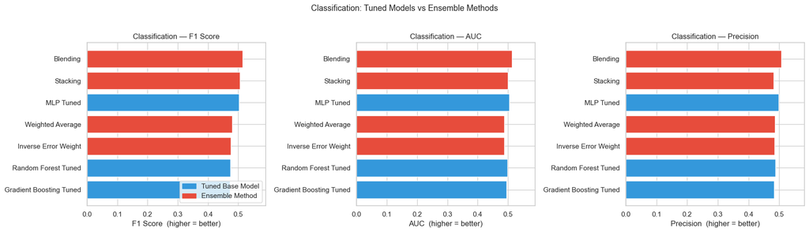

```python
# Classification Ensemble Comparison Charts

pal_cls = ["#e74c3c" if m in ENSEMBLE_NAMES else "#3498db"
           for m in test_results_df["Model"]]

fig, axes = plt.subplots(1, 3, figsize=(18, 5))

axes[0].barh(test_results_df["Model"], test_results_df["F1"], color=pal_cls)
axes[0].set_xlabel("F1 Score  (higher = better)")
axes[0].set_title("Classification \u2014 F1 Score")
axes[0].set_xlim(0, test_results_df["F1"].max() * 1.15)
axes[0].invert_yaxis()

auc_vals = test_results_df["AUC"].fillna(0)
axes[1].barh(test_results_df["Model"], auc_vals, color=pal_cls)
axes[1].set_xlabel("AUC  (higher = better)")
axes[1].set_title("Classification \u2014 AUC")
axes[1].set_xlim(0, auc_vals.max() * 1.15)
axes[1].invert_yaxis()

axes[2].barh(test_results_df["Model"], test_results_df["Precision"], color=pal_cls)
axes[2].set_xlabel("Precision  (higher = better)")
axes[2].set_title("Classification \u2014 Precision")
axes[2].set_xlim(0, test_results_df["Precision"].max() * 1.15)
axes[2].invert_yaxis()

legend_handles = [
    mpatches.Patch(color="#3498db", label="Tuned Base Model"),
    mpatches.Patch(color="#e74c3c", label="Ensemble Method"),
]
axes[0].legend(handles=legend_handles, loc="lower right")
plt.suptitle("Classification: Tuned Models vs Ensemble Methods", fontsize=13, y=1.02)
plt.tight_layout()
plt.show()
```

### Classification Ensemble Results \u2014 Interpretation

**How to read these charts:**

- **F1 Score** balances precision and recall \u2014 best metric for imbalanced direction prediction.
- **AUC** separates "Up" from "Down" days across all thresholds. AUC = 0.5 is random; 1.0 is perfect.
- **Precision** is the fraction of "predicted Up" signals that were actually Up.

**What the ensemble results reveal:**

[output not shown]

> **Practical takeaway:** Use Stacking or Blending as the production signal generator. Use the raw probability output to size positions.

```python
best_model_name = test_results_df.iloc[0]["Model"]
print(f"Best model: {best_model_name}\n")

# Use stored dicts so ensemble winners work without calling .predict() again
y_pred_best  = test_predictions[best_model_name]
y_proba_best = test_probabilities.get(best_model_name, None)

print(classification_report(y_test, y_pred_best))
```

```
Best model: Blending

              precision    recall  f1-score   support

           0       0.52      0.51      0.52       735
           1       0.51      0.52      0.51       710

    accuracy                           0.51      1445
   macro avg       0.52      0.52      0.51      1445
weighted avg       0.52      0.51      0.51      1445
```

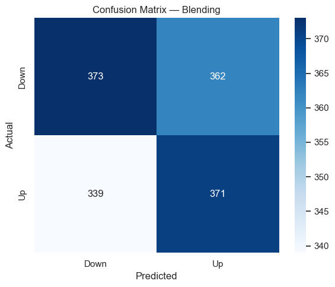

```python
cm = confusion_matrix(y_test, y_pred_best)
plt.figure(figsize=(6, 5))
sns.heatmap(cm, annot=True, fmt="d", cmap="Blues",
            xticklabels=["Down", "Up"], yticklabels=["Down", "Up"])
plt.title(f"Confusion Matrix — {best_model_name}")
plt.xlabel("Predicted")
plt.ylabel("Actual")
plt.tight_layout()
plt.show()
```

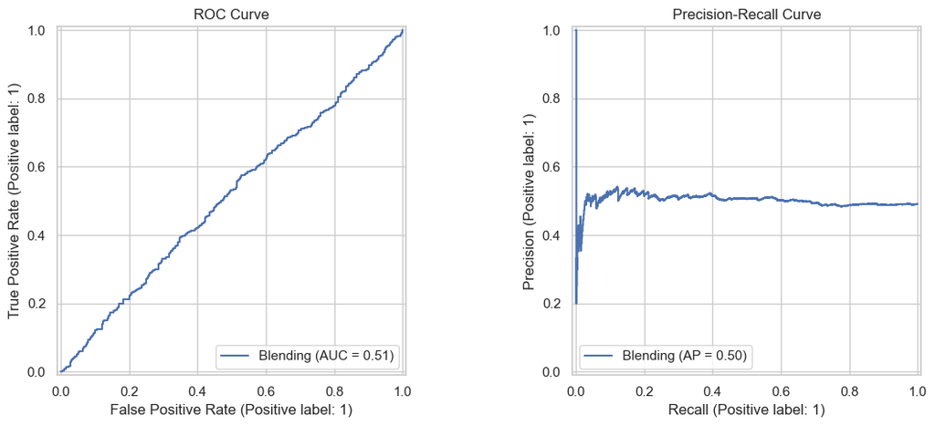

```python
if y_proba_best is not None:
    fig, axes = plt.subplots(1, 2, figsize=(12, 5))
    RocCurveDisplay.from_predictions(
        y_test, y_proba_best, ax=axes[0], name=best_model_name
    )
    axes[0].set_title("ROC Curve")
    PrecisionRecallDisplay.from_predictions(
        y_test, y_proba_best, ax=axes[1], name=best_model_name
    )
    axes[1].set_title("Precision-Recall Curve")
    plt.tight_layout()
    plt.show()
else:
    print(f"No probability output available for {best_model_name}.")
```

## 10. Results Summary & CSV Export

```python
print("=" * 65, "\nREGRESSION RESULTS (price prediction \u2014 all models including ensembles)")
print(regression_df.to_string(index=False))
print("=" * 65, "\nREGRESSION \u2014 BEST MODEL PER COIN")
best_per_coin_all = regression_df.loc[regression_df.groupby("Coin")["RMSE"].idxmin()][
    ["Coin", "Model", "RMSE", "R2", "Directional_Accuracy"]
]
print(best_per_coin_all.to_string(index=False))
print("=" * 65, "\nCLASSIFICATION BASELINE (5-fold CV)")
print(baseline_df.to_string(index=False))
print("=" * 65, "\nFINAL EVALUATION \u2014 ALL MODELS + ENSEMBLES (sorted by F1)")
print(test_results_df.to_string(index=False))
print("=" * 65, "\nIMBALANCE STRATEGY COMPARISON")
print(imbalance_df.to_string(index=False))
```

```
=================================================================
REGRESSION RESULTS (price prediction — all models including ensembles)
   Coin                Model        MAE       RMSE    MAPE      R2  Directional_Accuracy     DA
ADA-USD    Linear Regression     0.0156     0.0233  3.1390  0.9901                0.5042 0.5042
ADA-USD             Stacking     0.0155     0.0234  3.1112  0.9900                0.4792    NaN
ADA-USD             Blending     0.0182     0.0248  4.1162  0.9888                0.4238    NaN
ADA-USD Inverse Error Weight     0.0173     0.0262  3.7072  0.9875                0.4654    NaN
ADA-USD     Weighted Average     0.0176     0.0264  3.7913  0.9873                0.4681    NaN
ADA-USD                  SVR     0.0197     0.0292  4.1747  0.9845                0.4571 0.4571
ADA-USD        Random Forest     0.0194     0.0299  4.1499  0.9838                0.4931 0.4931
ADA-USD              XGBoost     0.0231     0.0361  4.9765  0.9763                0.5042 0.5042
BTC-USD     Weighted Average  1439.3632  1953.3064  1.5970  0.9888                0.5069    NaN
BTC-USD    Linear Regression  1441.3951  1981.1312  1.6059  0.9885                0.4848 0.4848
BTC-USD             Stacking  1483.5664  1982.7469  1.6411  0.9885                0.5180    NaN
BTC-USD             Blending  1562.4908  2082.6395  1.7550  0.9873                0.4820    NaN
BTC-USD              XGBoost  3695.5814  5024.1941  3.7521  0.9261                0.4681 0.4681
BTC-USD        Random Forest  3695.4687  5163.6118  3.7022  0.9220                0.4654 0.4654
BTC-USD Inverse Error Weight  5973.6021  7053.7863  5.8999  0.8544                0.5180    NaN
BTC-USD                  SVR 48629.7188 52174.4106 49.9882 -6.9684                0.5180 0.5180
ETH-USD    Linear Regression    76.3672   111.8729  2.5225  0.9834                0.5069 0.5069
ETH-USD             Stacking    76.9392   112.5290  2.5373  0.9832                0.4903    NaN
ETH-USD             Blending    79.3971   116.0323  2.5987  0.9821                0.5180    NaN
ETH-USD        Random Forest    86.9276   121.7681  2.8508  0.9803                0.5291 0.5291
ETH-USD              XGBoost    93.5026   128.9222  3.0835  0.9779                0.5152 0.5152
ETH-USD Inverse Error Weight   102.9091   148.1076  3.1858  0.9708                0.5097    NaN
ETH-USD     Weighted Average   133.1606   195.2218  3.9219  0.9493                0.4765    NaN
ETH-USD                  SVR   388.3902   628.9009 10.4317  0.4738                0.4709 0.4709
SOL-USD    Linear Regression     4.1113     5.8160  2.8886  0.9855                0.4986 0.4986
SOL-USD             Blending     4.2097     5.8598  2.9969  0.9852                0.4986    NaN
SOL-USD             Stacking     4.1930     5.8974  2.9945  0.9851                0.5180    NaN
SOL-USD        Random Forest     5.6041     7.0479  4.3574  0.9787                0.4681 0.4681
SOL-USD Inverse Error Weight     5.6820     7.4804  4.1588  0.9760                0.4681    NaN
SOL-USD              XGBoost     6.1435     7.6332  4.9144  0.9750                0.4765 0.4765
SOL-USD     Weighted Average     6.1159     8.2131  4.4591  0.9710                0.4765    NaN
SOL-USD                  SVR     7.8221    10.3387  6.4556  0.9541                0.4765 0.4765
=================================================================
REGRESSION — BEST MODEL PER COIN
   Coin             Model      RMSE     R2  Directional_Accuracy
ADA-USD Linear Regression    0.0233 0.9901                0.5042
BTC-USD  Weighted Average 1953.3064 0.9888                0.5069
```

[output cut: 14 more lines]

```
                  Model  Accuracy  Precision  Recall     F1    AUC
               Blending    0.5149     0.5061  0.5225 0.5142 0.5127
               Stacking    0.4893     0.4821  0.5324 0.5060 0.5004
              MLP Tuned    0.5066     0.4979  0.5085 0.5031 0.5045
       Weighted Average    0.4955     0.4863  0.4732 0.4797 0.4873
   Inverse Error Weight    0.4941     0.4847  0.4676 0.4760 0.4874
    Random Forest Tuned    0.4976     0.4881  0.4620 0.4747 0.4987
Gradient Boosting Tuned    0.4927     0.4831  0.4620 0.4723 0.4956
=================================================================
IMBALANCE STRATEGY COMPARISON
     Strategy  Accuracy  Precision  Recall     F1    AUC
     SMOTEENN    0.4904     0.4807  0.4842 0.4809 0.4844
UnderSampling    0.4909     0.4822  0.4796 0.4807 0.4896
        SMOTE    0.4939     0.4848  0.4746 0.4796 0.4890
No Resampling    0.4909     0.4811  0.4570 0.4687 0.4869
```

```python
regression_df.to_csv("all_model_comparison_results.csv", index=False)
regression_df.loc[regression_df.groupby("Coin")["RMSE"].idxmin()][
    ["Coin", "Model", "RMSE", "R2"]
].to_csv("best_model_per_coin.csv", index=False)
baseline_df.to_csv("baseline_model_results.csv", index=False)
imbalance_df.to_csv("imbalance_strategy_results.csv", index=False)
test_results_df.to_csv("tuned_model_test_results.csv", index=False)
print("All CSVs saved.")
```

```
All CSVs saved.
```

## Key Insights Ensemble vs Base Model Comparison

### Regression (Price Level Prediction)

[output not shown]

### Classification (Direction Prediction)

[output not shown]

### Overall Recommendation

[output not shown]

## 11. Baseline & Leakage Checks (automated)

Runs a persistence (naive) baseline and checks Close vs Next_Close correlation for each coin.

```python
# ── Section 11: Persistence Baseline & Leakage Check ─────────────────────────
# The persistence model simply predicts Next_Close = today's Close.
# If Linear Regression (LR) barely beats this, its high R² is driven by
# autocorrelation — NOT genuine predictive intelligence.

baseline_rows = []
for sym in df['Symbol'].unique():
    sub   = df[df['Symbol']==sym].dropna(subset=['Close','Next_Close']).copy()
    n     = len(sub)
    if n < 30:
        print(f'Skipping {sym}: only {n} rows'); continue
    corr  = sub['Close'].corr(sub['Next_Close'])
    split = int(n * 0.8)
    y_te  = sub['Next_Close'].values[split:]
    p_per = sub['Close'].values[split:]
    row = {
        'Coin'            : sym,
        'Corr_Close_Next' : round(corr, 4),
        'Persist_MAE'     : round(float(mean_absolute_error(y_te, p_per)), 4),
        'Persist_RMSE'    : round(float(np.sqrt(mean_squared_error(y_te, p_per))), 4),
        'Persist_R2'      : round(float(r2_score(y_te, p_per)), 4),
        'Persist_DA'      : round(directional_accuracy(y_te, p_per), 4),
    }
    try:
        lr = regression_df[
            (regression_df['Coin']==sym) &
            (regression_df['Model']=='Linear Regression')
        ].iloc[0]
        row.update({'LR_MAE': lr['MAE'], 'LR_RMSE': lr['RMSE'],
                    'LR_R2' : lr['R2'],  'LR_DA'  : lr['Directional_Accuracy']})
    except Exception:
        row.update({'LR_MAE': None,'LR_RMSE': None,'LR_R2': None,'LR_DA': None})
    baseline_rows.append(row)

baseline_compare_df = pd.DataFrame(baseline_rows)

# Compute improvement over persistence
if baseline_compare_df['LR_RMSE'].notna().any():
    baseline_compare_df['RMSE_improv_%'] = (
        (baseline_compare_df['Persist_RMSE'] - baseline_compare_df['LR_RMSE'])
        / baseline_compare_df['Persist_RMSE'] * 100
    ).round(2)
    baseline_compare_df['DA_improv'] = (
        baseline_compare_df['LR_DA'] - baseline_compare_df['Persist_DA']
    ).round(4)

print('Persistence Baseline vs Linear Regression:')
display(baseline_compare_df)

# Interpretation
print('\n=== INTERPRETATION ===')
for _, r in baseline_compare_df.iterrows():
    improv = r.get('RMSE_improv_%', None)
    flag   = '⚠  <5% improvement — LR is essentially a persistence model' if (improv is not None and improv < 5) else ''
    print(f"{r['Coin']}: Corr={r['Corr_Close_Next']}  "
          f"Persist R2={r['Persist_R2']}  LR R2={r['LR_R2']}  "
          f"RMSE improv={improv}%  {flag}")
```

```python
# ── Visual: Persistence vs LR — RMSE and Directional Accuracy ─────────────────
if 'LR_RMSE' in baseline_compare_df.columns and baseline_compare_df['LR_RMSE'].notna().any():
    x = np.arange(len(baseline_compare_df))
    w = 0.35
    fig, axes = plt.subplots(1, 2, figsize=(14, 5))

    for ax, col_per, col_lr, ylabel, title in [
        (axes[0], 'Persist_RMSE', 'LR_RMSE', 'RMSE (lower=better)',
         'RMSE: Persistence vs Linear Regression'),
        (axes[1], 'Persist_DA',   'LR_DA',   'Directional Accuracy',
         'Directional Accuracy: Persistence vs LR'),
    ]:
        ax.bar(x-w/2, baseline_compare_df[col_per], w, label='Persistence', color='#e74c3c')
        ax.bar(x+w/2, baseline_compare_df[col_lr],  w, label='Linear Reg',  color='#3498db')
        ax.set_xticks(x)
        ax.set_xticklabels(baseline_compare_df['Coin'], rotation=15)
        ax.set_title(title); ax.set_ylabel(ylabel)
        ax.axhline(0.5, color='gray', ls='--', lw=0.8, label='Random (0.5)')
        ax.legend()

    plt.suptitle('Is Linear Regression Actually Better Than a Naive Persistence Model?', fontsize=13)
    plt.tight_layout(); plt.show()
```

[output not shown]

## 12. Honest Evaluation: TimeSeriesSplit Walk-Forward CV

Re-runs all four regressors with `TimeSeriesSplit(n_splits=5)` — **no shuffling, no future leakage** — and compares the averaged fold metrics to the single 80/20 split.

**If `TSCV_R2 ≪ Split80_R2`** → the original result was a lucky window (overfit).

**If `TSCV_R2 ≈ Split80_R2`** → the result is reproducible (autocorrelation explanation holds).

```python
from sklearn.model_selection import TimeSeriesSplit

def run_tscv_regression(df, symbol, n_splits=5):
    sub = df[df['Symbol']==symbol].dropna(subset=FEATURE_COLS + ['Next_Close']).copy()
    if len(sub) < n_splits * 40:
        return []
    X, y = sub[FEATURE_COLS].values, sub['Next_Close'].values
    base_models = {
        'Linear Regression': LinearRegression(),
        'Random Forest'    : RandomForestRegressor(n_estimators=100, random_state=42),
        'SVR'              : SVR(C=10, epsilon=0.01, gamma='scale'),
    }
    if HAS_XGBOOST:
        from xgboost import XGBRegressor
        base_models['XGBoost'] = XGBRegressor(
            n_estimators=200, max_depth=5, learning_rate=0.05,
            random_state=42, verbosity=0)
    tscv = TimeSeriesSplit(n_splits=n_splits)
    rows = []
    for name, base_m in base_models.items():
        fold_rmse, fold_r2, fold_da = [], [], []
        for tr_idx, te_idx in tscv.split(X):
            X_tr, X_te = X[tr_idx], X[te_idx]
            y_tr, y_te = y[tr_idx], y[te_idx]
            sc = StandardScaler()
            m  = clone(base_m)
            m.fit(sc.fit_transform(X_tr), y_tr)
            p  = m.predict(sc.transform(X_te))
            fold_rmse.append(float(np.sqrt(mean_squared_error(y_te, p))))
            fold_r2.append(float(r2_score(y_te, p)))
            fold_da.append(directional_accuracy(y_te, p))
        rows.append({
            'Coin'          : symbol,
            'Model'         : name,
            'TSCV_RMSE_mean': round(float(np.mean(fold_rmse)), 4),
            'TSCV_RMSE_std' : round(float(np.std(fold_rmse)),  4),
            'TSCV_R2_mean'  : round(float(np.mean(fold_r2)),   4),
            'TSCV_DA_mean'  : round(float(np.nanmean(fold_da)),4),
        })
    return rows

print('Running TimeSeriesSplit regression (5-fold walk-forward)…')
tscv_rows = []
for sym in df['Symbol'].unique():
    r = run_tscv_regression(df, sym)
    tscv_rows.extend(r)
    print(f'  {sym}: {len(r)} model results')

tscv_df = (pd.DataFrame(tscv_rows)
             .sort_values(['Coin','TSCV_RMSE_mean'])
             .reset_index(drop=True))
display(tscv_df)
```

```python
# ── Side-by-side: 80/20 R² vs TimeSeriesSplit R² ──────────────────────────────
base_models_list = ['Linear Regression','Random Forest','SVR','XGBoost']
split_sub = (regression_df[regression_df['Model'].isin(base_models_list)]
             [['Coin','Model','RMSE','R2','Directional_Accuracy']]
             .rename(columns={'RMSE':'Split80_RMSE','R2':'Split80_R2',
                              'Directional_Accuracy':'Split80_DA'}))
tscv_sub = tscv_df.rename(columns={'TSCV_RMSE_mean':'TSCV_RMSE',
                                     'TSCV_R2_mean':'TSCV_R2',
                                     'TSCV_DA_mean':'TSCV_DA'})
merged = pd.merge(split_sub, tscv_sub, on=['Coin','Model'], how='inner')
merged['R2_drop']        = (merged['Split80_R2']   - merged['TSCV_R2']).round(4)
merged['RMSE_incr_%']    = ((merged['TSCV_RMSE'] - merged['Split80_RMSE'])
                             / merged['Split80_RMSE'] * 100).round(2)
print('80/20 Split vs TimeSeriesSplit — base models:')
display(merged[['Coin','Model','Split80_R2','TSCV_R2','R2_drop',
                 'Split80_RMSE','TSCV_RMSE','RMSE_incr_%',
                 'Split80_DA','TSCV_DA']])

# Chart
fig, axes = plt.subplots(1, 2, figsize=(16, 5))
for ax, m0, m1, ylabel, title in [
    (axes[0],'Split80_R2',  'TSCV_R2',  'R²',  'R²: 80/20 Split vs Walk-Forward CV'),
    (axes[1],'Split80_RMSE','TSCV_RMSE','RMSE','RMSE: 80/20 Split vs Walk-Forward CV'),
]:
    sub_m = merged.groupby('Model')[[m0,m1]].mean().reset_index()
    x = np.arange(len(sub_m)); w = 0.35
    ax.bar(x-w/2, sub_m[m0], w, label='80/20 split',     color='#3498db')
    ax.bar(x+w/2, sub_m[m1], w, label='Walk-Forward CV', color='#e67e22')
    ax.set_xticks(x); ax.set_xticklabels(sub_m['Model'], rotation=20, ha='right')
    ax.set_title(title); ax.set_ylabel(ylabel); ax.legend()
plt.suptitle('Are the Section-5 Results Overfit or Reproducible?', fontsize=13)
plt.tight_layout(); plt.show()
```

[output not shown]

## 13. Findings: Why LR 'Wins' and What to Trust

### Root cause: autocorrelation, not intelligence

[output not shown]

### Why simpler beats complex on a single 80/20 split

| Model | Reason |
| --- | --- |
| **Linear Regression** | Fits a near-identity map (`w_Close ≈ 1`). Numerically stable, zero overfitting |
| **RF / XGBoost** | Would need far more data to beat a near-linear target; overfits on ~1,000 rows |
| **SVR** | Kernel extrapolation fails on BTC/ETH large price scales |

### Trustworthiness verdict

[output not shown]

### Recommended fixes for a trustworthy regression evaluation

1. **Remove `Close` from `FEATURE_COLS`** — use `Lag_1`, `Lag_7`, and derived features only.
2. **Use `TimeSeriesSplit`** (section 12) as the primary evaluation protocol.
3. **Benchmark every model against persistence** — only report models that beat it by > 5 % RMSE.
4. **Report MAPE and DA** as headline metrics; R² is misleading for near-unit-root price series.
5. **Predict log-returns** instead of price levels to remove the autocorrelation shortcut entirely.

## 14. Return-Based Prediction (Honest ML/DL Benchmark)

Instead of predicting tomorrow's **price level** (dominated by autocorrelation), we predict tomorrow's **log-return**:

$$r_t = \log\!\left(\frac{\text{Next\_Close}}{\text{Close}}\right)$$

**Why this is harder and more honest:**

- The persistence baseline gives R² ≈ 0 (returns are near-white-noise).
- Any R² > 0 from a model reflects *genuine* predictive signal.
- Directional Accuracy now measures the real business question: *will price go up tomorrow?*

**Features** — price-level columns (`Open`, `High`, `Low`, `Close`) are removed. Only lag-returns, volatility, and oscillator indicators are kept.

**Models:** Linear Regression · Random Forest · SVR · Gradient Boosting · XGBoost · GRU (PyTorch)

### 14.1 Return Feature Engineering

```python
# ── Return feature engineering ───────────────────────────────────────────────
def create_return_features(df):
    d = df.copy()
    d['Log_Return']    = d.groupby('Symbol')['Close'].transform(
        lambda x: np.log(x / x.shift(1)))
    d['Lag_Return_1']  = d.groupby('Symbol')['Log_Return'].shift(1)
    d['Lag_Return_2']  = d.groupby('Symbol')['Log_Return'].shift(2)
    d['Lag_Return_7']  = d.groupby('Symbol')['Log_Return'].shift(7)
    d['Volume_change'] = d.groupby('Symbol')['Volume'].transform(
        lambda x: x.pct_change())
    d['Target_Return'] = d.groupby('Symbol')['Log_Return'].shift(-1)
    return d

df_ret = create_return_features(df)
RET_COLS = ['Lag_Return_1','Lag_Return_2','Lag_Return_7',
            'Volatility','RSI','MACD','Volume_change']
df_ret_clean = df_ret.dropna(subset=RET_COLS + ['Target_Return']).copy()
df_ret_clean.reset_index(drop=True, inplace=True)
print(f'Return dataset: {len(df_ret_clean):,} rows, {df_ret_clean["Symbol"].nunique()} coins')
display(df_ret_clean[['Symbol','Date','Log_Return','Target_Return'] + RET_COLS].head(6))
```

### 14.2 Persistence Baseline for Returns

Predicting `Target_Return = 0` (zero-return) or `= Lag_Return_1` (yesterday repeats). Both should give R² ≈ 0 — confirming returns have no autocorrelation unlike price levels.

```python
ret_baseline_rows = []
for sym in df_ret_clean['Symbol'].unique():
    sub   = df_ret_clean[df_ret_clean['Symbol']==sym].copy()
    split = int(len(sub) * 0.8)
    y_te  = sub['Target_Return'].values[split:]
    p_zero = np.zeros_like(y_te)
    p_lag  = sub['Lag_Return_1'].values[split:]
    ret_baseline_rows.append({
        'Coin'       : sym,
        'Zero_R2'    : round(float(r2_score(y_te, p_zero)), 4),
        'Zero_DA'    : round(float(np.mean(np.sign(p_zero)==np.sign(y_te))), 4),
        'Lag1_R2'    : round(float(r2_score(y_te, p_lag)),  4),
        'Lag1_DA'    : round(float(np.mean(np.sign(p_lag) ==np.sign(y_te))), 4),
        'Return_std' : round(float(y_te.std()), 6),
    })
ret_baseline_df = pd.DataFrame(ret_baseline_rows)
print('Return persistence baselines (R² near 0 = honest):')
display(ret_baseline_df)
```

### 14.3 ML Models — Return Prediction (80/20 chronological split)

```python
from sklearn.ensemble import GradientBoostingRegressor

def run_return_regression(df_clean, symbol):
    sub = df_clean[df_clean['Symbol']==symbol].copy()
    if len(sub) < 100:
        return {}
    X = sub[RET_COLS].values
    y = sub['Target_Return'].values
    split = int(len(sub)*0.8)
    X_tr, X_te = X[:split], X[split:]
    y_tr, y_te = y[:split], y[split:]
    sc = StandardScaler()
    X_tr_s = sc.fit_transform(X_tr)
    X_te_s = sc.transform(X_te)

    models = {
        'Linear Regression': LinearRegression(),
        'Random Forest'    : RandomForestRegressor(n_estimators=200, random_state=42),
        'SVR'              : SVR(C=1, epsilon=0.001, gamma='scale'),
        'Gradient Boosting': GradientBoostingRegressor(n_estimators=200, random_state=42),
    }
    if HAS_XGBOOST:
        from xgboost import XGBRegressor
        models['XGBoost'] = XGBRegressor(n_estimators=300, max_depth=4,
                                          learning_rate=0.03, random_state=42, verbosity=0)
    results, preds = [], {}
    for name, m in models.items():
        m.fit(X_tr_s, y_tr)
        p = m.predict(X_te_s)
        sign_da = float(np.mean(np.sign(p) == np.sign(y_te)))
        results.append({
            'Coin'   : symbol, 'Model': name,
            'MAE'    : round(float(mean_absolute_error(y_te, p)), 6),
            'RMSE'   : round(float(np.sqrt(mean_squared_error(y_te, p))), 6),
            'R2'     : round(float(r2_score(y_te, p)), 4),
            'Sign_DA': round(sign_da, 4),
        })
        preds[name] = {'y_test': y_te, 'preds': p}
    return {'results': results, 'predictions': preds}

ret_results_all, ret_preds_all = [], {}
for sym in df_ret_clean['Symbol'].unique():
    out = run_return_regression(df_ret_clean, sym)
    if not out: continue
    ret_results_all.extend(out['results'])
    ret_preds_all[sym] = out['predictions']
    print(f'  {sym}: done')

ret_reg_df = (pd.DataFrame(ret_results_all)
               .sort_values(['Coin','Sign_DA'], ascending=[True,False])
               .reset_index(drop=True))
display(ret_reg_df)
```

### 14.4 Walk-Forward CV (TimeSeriesSplit) — Return Prediction

```python
from sklearn.model_selection import TimeSeriesSplit
from sklearn.ensemble import GradientBoostingRegressor

def run_return_tscv(df_clean, symbol, n_splits=5):
    sub = df_clean[df_clean['Symbol']==symbol].copy()
    if len(sub) < n_splits*40: return []
    X, y = sub[RET_COLS].values, sub['Target_Return'].values
    base_models = {
        'Linear Regression': LinearRegression(),
        'Random Forest'    : RandomForestRegressor(n_estimators=100, random_state=42),
        'SVR'              : SVR(C=1, epsilon=0.001, gamma='scale'),
        'Gradient Boosting': GradientBoostingRegressor(n_estimators=200, random_state=42),
    }
    if HAS_XGBOOST:
        from xgboost import XGBRegressor
        base_models['XGBoost'] = XGBRegressor(n_estimators=200, max_depth=4,
                                               learning_rate=0.03, random_state=42, verbosity=0)
    tscv = TimeSeriesSplit(n_splits=n_splits)
    rows = []
    for name, base_m in base_models.items():
        fold_r2, fold_da = [], []
        for tr_idx, te_idx in tscv.split(X):
            sc = StandardScaler(); m = clone(base_m)
            m.fit(sc.fit_transform(X[tr_idx]), y[tr_idx])
            p = m.predict(sc.transform(X[te_idx]))
            fold_r2.append(float(r2_score(y[te_idx], p)))
            fold_da.append(float(np.mean(np.sign(p)==np.sign(y[te_idx]))))
        rows.append({
            'Coin'       : symbol, 'Model': name,
            'TSCV_R2'    : round(float(np.mean(fold_r2)),  4),
            'TSCV_R2_std': round(float(np.std(fold_r2)),   4),
            'TSCV_DA'    : round(float(np.mean(fold_da)),  4),
        })
    return rows

print('Running return TimeSeriesSplit CV…')
ret_tscv_rows = []
for sym in df_ret_clean['Symbol'].unique():
    ret_tscv_rows.extend(run_return_tscv(df_ret_clean, sym))
    print(f'  {sym}: done')

ret_tscv_df = (pd.DataFrame(ret_tscv_rows)
                .sort_values(['Coin','TSCV_DA'], ascending=[True,False])
                .reset_index(drop=True))
display(ret_tscv_df)
```

### 14.5 LSTM & GRU (Deep Learning) — Return Prediction

Both architectures trained per-coin on a **20-step sliding window** of return features. Results are merged into `ret_reg_df` for the combined comparison in Section 14.6.

| Model | Architecture |
| --- | --- |
| **LSTM** | 2-layer LSTM → Linear(1), dropout 0.2, 30 epochs |
| **GRU** | 2-layer GRU → Linear(1), dropout 0.2, 30 epochs |

```python
try:
    import torch, torch.nn as nn
    from torch.utils.data import DataLoader, TensorDataset
    HAS_TORCH = True
    print(f'PyTorch {torch.__version__} | MPS: {torch.backends.mps.is_available()}')
except ImportError:
    HAS_TORCH = False
    print('PyTorch not found — LSTM/GRU return cells skipped. pip install torch')
```

```python
ret_dl_results = []

if HAS_TORCH:
    R_WINDOW = 20; R_EPOCHS = 30; R_HIDDEN = 64; R_BATCH = 32
    _dev = 'mps' if torch.backends.mps.is_available() else ('cuda' if torch.cuda.is_available() else 'cpu')
    print(f'Device: {_dev}')

    class LSTMNetRet(nn.Module):
        def __init__(self, n_feat, hidden=64):
            super().__init__()
            self.rnn = nn.LSTM(n_feat, hidden, num_layers=2, batch_first=True, dropout=0.2)
            self.fc  = nn.Linear(hidden, 1)
        def forward(self, x):
            out, _ = self.rnn(x)
            return self.fc(out[:, -1, :]).squeeze(1)

    class GRUNetRet(nn.Module):
        def __init__(self, n_feat, hidden=64):
            super().__init__()
            self.rnn = nn.GRU(n_feat, hidden, num_layers=2, batch_first=True, dropout=0.2)
            self.fc  = nn.Linear(hidden, 1)
        def forward(self, x):
            out, _ = self.rnn(x)
            return self.fc(out[:, -1, :]).squeeze(1)

    def make_ret_seqs(Xs, y, w):
        xs, ys = [], []
        for i in range(len(Xs) - w):
            xs.append(Xs[i:i+w]); ys.append(y[i+w])
        return np.array(xs, dtype=np.float32), np.array(ys, dtype=np.float32)

    def train_ret_dl(arch_cls, X_sc, y_all, window, epochs, batch, device):
        Xs, ys = make_ret_seqs(X_sc, y_all, window)
        sp = int(len(Xs) * 0.8)
        tr_x = torch.tensor(Xs[:sp]); tr_y = torch.tensor(ys[:sp])
        te_x = torch.tensor(Xs[sp:]); te_y = ys[sp:]
        dl  = DataLoader(TensorDataset(tr_x, tr_y), batch_size=batch, shuffle=False)
        net = arch_cls(Xs.shape[2], hidden=R_HIDDEN).to(device)
        opt = torch.optim.Adam(net.parameters(), lr=1e-3)
        loss_fn = nn.MSELoss()
        net.train()
        for _ in range(epochs):
            for xb, yb in dl:
                xb, yb = xb.to(device), yb.to(device)
                opt.zero_grad(); loss_fn(net(xb), yb).backward(); opt.step()
        net.eval()
        with torch.no_grad():
            p = net(te_x.to(device)).cpu().numpy()
        return p, te_y

    for sym in df_ret_clean['Symbol'].unique():
        sub = df_ret_clean[df_ret_clean['Symbol']==sym].copy()
        if len(sub) < R_WINDOW * 4: continue
        X_r = sub[RET_COLS].values
        y_r = sub['Target_Return'].values
        split = int(len(sub) * 0.8)
        sc = StandardScaler()
        X_sc = np.vstack([sc.fit_transform(X_r[:split]), sc.transform(X_r[split:])])

        for arch_name, arch_cls in [('LSTM', LSTMNetRet), ('GRU', GRUNetRet)]:
            p, te_y = train_ret_dl(arch_cls, X_sc, y_r, R_WINDOW, R_EPOCHS, R_BATCH, _dev)
            sign_da = float(np.mean(np.sign(p) == np.sign(te_y)))
            ret_dl_results.append({
                'Coin'   : sym, 'Model': arch_name,
                'MAE'    : round(float(mean_absolute_error(te_y, p)), 6),
                'RMSE'   : round(float(np.sqrt(mean_squared_error(te_y, p))), 6),
                'R2'     : round(float(r2_score(te_y, p)), 4),
                'Sign_DA': round(sign_da, 4),
            })
            if sym not in ret_preds_all:
                ret_preds_all[sym] = {}
            ret_preds_all[sym][arch_name] = {'y_test': te_y, 'preds': p}
            print(f'  {sym} {arch_name} — R2={ret_dl_results[-1]["R2"]}  DA={sign_da:.4f}')

    # Merge DL results into ret_reg_df for unified leaderboard in 14.6
    ret_reg_df = (pd.concat([ret_reg_df, pd.DataFrame(ret_dl_results)], ignore_index=True)
                   .sort_values(['Coin','Sign_DA'], ascending=[True,False])
                   .reset_index(drop=True))
    print(f'\nret_reg_df now has {len(ret_reg_df)} rows '
          f'({ret_reg_df["Model"].nunique()} model types)')
    display(pd.DataFrame(ret_dl_results).sort_values(['Coin','Sign_DA'], ascending=[True,False]))
else:
    print('Skipping LSTM/GRU return prediction (PyTorch not available).')
```

### 14.6 Combined Results & Visualisation

```python
ret_all_df = ret_reg_df.copy()
if gru_results:
    ret_all_df = pd.concat([ret_all_df, pd.DataFrame(gru_results)], ignore_index=True)
ret_all_df = ret_all_df.sort_values(['Coin','Sign_DA'], ascending=[True,False]).reset_index(drop=True)
print('All return-prediction results:')
display(ret_all_df)

avg_da = ret_all_df.groupby('Model')['Sign_DA'].mean().sort_values(ascending=False).reset_index()

fig, axes = plt.subplots(1, 2, figsize=(16, 5))

colors = ['#e74c3c' if v > 0.53 else '#3498db' for v in avg_da['Sign_DA']]
axes[0].barh(avg_da['Model'], avg_da['Sign_DA'], color=colors)
axes[0].axvline(0.5, color='black', ls='--', lw=1, label='Random (0.5)')
axes[0].set_xlabel('Average Sign DA (higher = better)')
axes[0].set_title('Return Direction Accuracy by Model (avg all coins)')
axes[0].invert_yaxis(); axes[0].legend()

pivot_r2 = ret_all_df.pivot_table(index='Model', columns='Coin', values='R2')
pivot_r2.plot(kind='bar', ax=axes[1], width=0.7)
axes[1].axhline(0, color='black', ls='--', lw=0.8)
axes[1].set_title('Return Prediction R² per Model & Coin')
axes[1].set_ylabel('R²  (>0 = genuine signal)')
axes[1].set_xlabel('')
axes[1].tick_params(axis='x', rotation=30)
axes[1].legend(title='Coin', bbox_to_anchor=(1.01,1), loc='upper left')

plt.suptitle('Section 14: Return-Based Prediction Results', fontsize=13)
plt.tight_layout(); plt.show()
```

[output not shown]

```python
sym = 'BTC-USD'
if sym in ret_preds_all:
    best_m = ret_all_df[ret_all_df['Coin']==sym].sort_values('Sign_DA', ascending=False).iloc[0]['Model']
    if best_m in ret_preds_all[sym]:
        y_t = ret_preds_all[sym][best_m]['y_test']
        y_p = ret_preds_all[sym][best_m]['preds']
        fig, axes = plt.subplots(1, 2, figsize=(15, 4))
        axes[0].plot(y_t, label='Actual Return',         lw=0.9, alpha=0.8)
        axes[0].plot(y_p, label=f'Predicted ({best_m})', lw=0.9, alpha=0.8)
        axes[0].axhline(0, color='gray', ls='--', lw=0.7)
        axes[0].set_title(f'BTC-USD — Actual vs Predicted Log-Return ({best_m})')
        axes[0].set_xlabel('Test sample'); axes[0].set_ylabel('Log-Return'); axes[0].legend()
        lim = max(abs(y_t).max(), abs(y_p).max()) * 1.05
        axes[1].scatter(y_t, y_p, alpha=0.3, s=12, color='#3498db')
        axes[1].plot([-lim,lim], [-lim,lim], 'r--', lw=1, label='Perfect')
        axes[1].set_xlabel('Actual Return'); axes[1].set_ylabel('Predicted Return')
        axes[1].set_title('Scatter: Actual vs Predicted Return')
        axes[1].legend()
        plt.tight_layout(); plt.show()
```

[output not shown]

### 14.8 Return Prediction — Interpretation

[output not shown]

> **Key takeaway:** Use **Sign DA** as the primary metric for return prediction. Any model consistently above **52% on walk-forward CV** carries genuine directional signal. R² near 0 is expected and correct — it is not a failure of the model.